# Statistical analysis for Drosophila NSC mosaicism manuscript

Author

Abhilesh Dhawanjewar

Published

August 28, 2026

**Load libraries and data**

```r
library(here)
library(tidyverse)
library(conflicted)
library(lme4)
library(lmerTest)
library(DHARMa)
library(emmeans)
library(kableExtra)
# car, nlme, reactable, htmltools are called via :: only (no attach, no conflicts)

conflicts_prefer(
    dplyr::filter, dplyr::select, dplyr::rename, dplyr::lag,
    lmerTest::lmer, .quiet = TRUE
)

# Reproducibility: a fixed global seed plus deterministic Monte-Carlo quantiles
# for emmeans multivariate-t contrasts (otherwise the p-values vary).
GLOBAL_SEED <- 42L
DHARMA_SEED <- 42L
set.seed(GLOBAL_SEED)
emmeans::emm_options(rng.seed = GLOBAL_SEED)

stat_data_dir    <- here("statistical_analysis", "data")
stat_results_dir <- here("results", "statistical_analysis")
if (!dir.exists(stat_data_dir)) {
    stop("Analysis data not found at ", stat_data_dir)
}
dir.create(stat_results_dir, recursive = TRUE, showWarnings = FALSE)

# Read one per-analysis data table (one row per clone / brain / cell).
read_stat <- function(name) {
    readr::read_csv(file.path(stat_data_dir, name), show_col_types = FALSE)
}

# Write one result table to results/statistical_analysis/.
write_result <- function(x, name) {
    df <- as.data.frame(x)
    rn <- rownames(df)
    if (!is.null(rn) && !identical(rn, as.character(seq_len(nrow(df))))) {
        df <- tibble::rownames_to_column(df, "term")
    }
    readr::write_csv(df, file.path(stat_results_dir, name))
    invisible(df)
}

minimal_tbl <- function(df) {
    df %>%
        kbl(align = "c") %>%
        kable_styling(
            bootstrap_options = c("condensed", "bordered"),
            full_width        = FALSE,
            position          = "left"
        )
}

fmt_p <- function(p, digits = 2) {
    if (is.na(p)) return("NA")
    if (p < 0.001) {
        sci   <- formatC(p, format = "e", digits = digits - 1)
        parts <- strsplit(sci, "e")[[1]]
        exp   <- as.integer(parts[2])
        return(paste0(trimws(parts[1]), " \\times 10^{", exp, "}"))
    }
    as.character(signif(p, max(digits, 2)))
}

sig_stars <- function(p, na_as = "") {
    case_when(
        is.na(p)  ~ na_as,
        p < 0.001 ~ "***",
        p < 0.01  ~ "**",
        p < 0.05  ~ "*",
        TRUE      ~ "ns"
    )
}

sig_tbl <- function(df) {
    sig_col <- intersect(c("sig", "sig_label"), names(df))[1]
    if (is.na(sig_col)) return(minimal_tbl(df))

    sig_vals <- df[[sig_col]]
    rows_3 <- which(sig_vals == "***")
    rows_2 <- which(sig_vals == "**")
    rows_1 <- which(sig_vals == "*")

    df[[sig_col]] <- dplyr::case_when(
        sig_vals == "***" ~ kableExtra::cell_spec(sig_vals, bold = TRUE, color = "#1a7b1a"),
        sig_vals == "**"  ~ kableExtra::cell_spec(sig_vals, bold = TRUE, color = "#2d8a2d"),
        sig_vals == "*"   ~ kableExtra::cell_spec(sig_vals, bold = TRUE, color = "#5aaa5a"),
        sig_vals == "ns"  ~ kableExtra::cell_spec(sig_vals, color = "#999999"),
        TRUE ~ sig_vals
    )

    tbl <- df %>%
        kbl(align = "c", escape = FALSE) %>%
        kable_styling(
            bootstrap_options = c("condensed", "bordered"),
            full_width        = FALSE,
            position          = "left"
        )

    if (length(rows_3) > 0) tbl <- tbl %>% row_spec(rows_3, background = "#c8e6c9")
    if (length(rows_2) > 0) tbl <- tbl %>% row_spec(rows_2, background = "#def0de")
    if (length(rows_1) > 0) tbl <- tbl %>% row_spec(rows_1, background = "#f0faf0")

    tbl
}
```

## Fig 1B: NSC lineage size

NSC lineage size (progeny per NSC clone) is compared across Control, Complex I, and Complex V RNAi, one clone per row. Two mosaic systems affect different fractions of NSCs and are analysed as separate models:

- **Most NSCs affected:** `worniu-GAL4, Tub-FRT-Stop-FRT-GFP`
- **Few NSCs affected:** `Actin-FRT-Stop-FRT-GAL4, UAS-mCD8-GFP`

Brains are the biological replicate and enter each panel’s model as a random intercept:

`lineage_size ~ rnai + (1 | brain_uid)`

Complex I and Complex V RNAi are each compared to the panel-matched Control RNAi, with a multivariate-$t$ adjustment across the two comparisons within a panel.

**Load Fig 1B lineage-size data and tabulate clones and brains per group**

```r
fig1b_df <- read_stat("fig_01b_lineage_size.csv") %>%
    filter(!is.na(value)) %>%
    transmute(
        lineage_size = value,
        genotype     = genotype,
        panel = factor(
            if_else(panel_side == "left", "Most NSCs affected", "Few NSCs affected"),
            levels = c("Most NSCs affected", "Few NSCs affected")
        ),
        rnai      = factor(rnai, levels = c("Control", "Complex I", "Complex V")),
        brain_uid = factor(replicate_id)
    )

fig1b_df %>%
    group_by(panel, rnai) %>%
    summarise(
        n_clones = n(),
        n_brains = n_distinct(brain_uid),
        .groups  = "drop"
    ) %>%
    minimal_tbl()
```

| panel | rnai | n_clones | n_brains |
| --- | --- | --- | --- |
| Most NSCs affected | Control | 46 | 6 |
| Most NSCs affected | Complex I | 22 | 6 |
| Most NSCs affected | Complex V | 24 | 5 |
| Few NSCs affected | Control | 33 | 4 |
| Few NSCs affected | Complex I | 40 | 6 |
| Few NSCs affected | Complex V | 26 | 4 |

### Diagnostics

**Fit panel-specific linear mixed-effects models**

```r
fig1b_most_df <- fig1b_df %>% filter(panel == "Most NSCs affected")
fig1b_few_df  <- fig1b_df %>% filter(panel == "Few NSCs affected")

fig1b_most_model <- lmerTest::lmer(
    lineage_size ~ rnai + (1 | brain_uid),
    data = fig1b_most_df,
    REML = TRUE
)

fig1b_few_model <- lmerTest::lmer(
    lineage_size ~ rnai + (1 | brain_uid),
    data = fig1b_few_df,
    REML = TRUE
)

summary(fig1b_most_model)
summary(fig1b_few_model)
```

**NoteModel fit diagnostics with DHARMa**

Scaled residuals from 1,000 simulations are tested for uniform distribution (Kolmogorov–Smirnov), dispersion, and an excess of outliers; all three should be non-significant for a well-fitting model.

**Run DHARMa diagnostics**

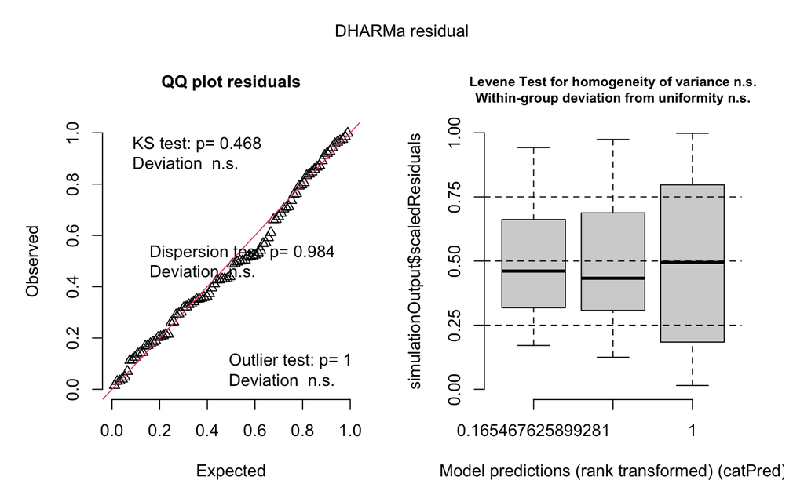

```r
sim_fig1b_most <- DHARMa::simulateResiduals(fig1b_most_model, n = 1000, seed = DHARMA_SEED)
sim_fig1b_few  <- DHARMa::simulateResiduals(fig1b_few_model,  n = 1000, seed = DHARMA_SEED)

plot(sim_fig1b_most)
```

**Run DHARMa diagnostics**

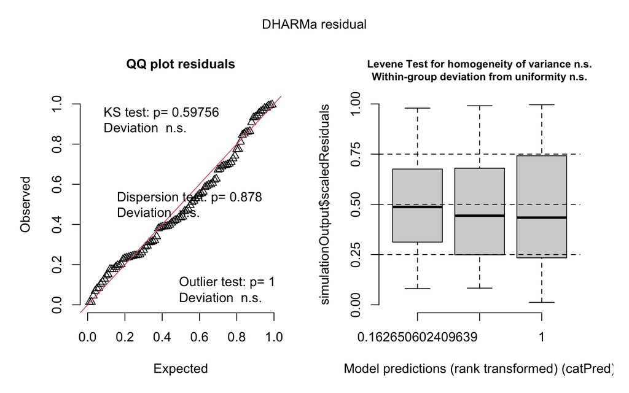

```r
plot(sim_fig1b_few)
```

**Run DHARMa diagnostics**

```r
invisible(capture.output(
    fig1b_dharma_tests <- list(
        most_uniformity     = DHARMa::testUniformity(sim_fig1b_most, plot = FALSE),
        most_dispersion     = DHARMa::testDispersion(sim_fig1b_most, plot = FALSE),
        most_outliers = DHARMa::testOutliers(sim_fig1b_most, plot = FALSE),
        few_uniformity      = DHARMa::testUniformity(sim_fig1b_few,  plot = FALSE),
        few_dispersion      = DHARMa::testDispersion(sim_fig1b_few,  plot = FALSE),
        few_outliers  = DHARMa::testOutliers(sim_fig1b_few,  plot = FALSE)
    )
))

fig1b_dharma_tests %>%
    purrr::map_dfr(
        \(t) tibble(statistic = t$statistic, p.value = t$p.value),
        .id = "test"
    ) %>%
    mutate(across(where(is.numeric), \(x) signif(x, 3)), sig = sig_stars(p.value)) %>%
    minimal_tbl()
```

| test | statistic | p.value | sig |
| --- | --- | --- | --- |
| most_uniformity | 0.0884 | 0.468 | ns |
| most_dispersion | 0.9960 | 0.984 | ns |
| most_outliers | 0.0000 | 1.000 | ns |
| few_uniformity | 0.0772 | 0.598 | ns |
| few_dispersion | 0.9730 | 0.878 | ns |
| few_outliers | 0.0000 | 1.000 | ns |

### Global F-test

Type III ANOVA F-test of the `rnai` term, shown separately for each panel.

**Type III ANOVA**

```r
bind_rows(
    anova(fig1b_most_model, type = "III", ddf = "Satterthwaite") %>%
        as.data.frame() %>%
        tibble::rownames_to_column("term") %>%
        mutate(panel = "Most NSCs affected"),
    anova(fig1b_few_model,  type = "III", ddf = "Satterthwaite") %>%
        as.data.frame() %>%
        tibble::rownames_to_column("term") %>%
        mutate(panel = "Few NSCs affected")
) %>%
    rename(df_num = NumDF, df_den = DenDF, F = `F value`, p.value = `Pr(>F)`) %>%
    select(panel, term, everything()) %>%
    mutate(across(where(is.numeric), \(x) signif(x, 3)), sig = sig_stars(p.value)) %>%
    sig_tbl()
```

| panel | term | Sum Sq | Mean Sq | df_num | df_den | F | p.value | sig |
| --- | --- | --- | --- | --- | --- | --- | --- | --- |
| Most NSCs affected | rnai | 17500 | 8770 | 2 | 15.2 | 41.60 | 7.00e-07 | *** |
| Few NSCs affected | rnai | 3240 | 1620 | 2 | 96.0 | 3.04 | 5.27e-02 | ns |

### Complex I and Complex V RNAi vs. Control RNAi, per panel (multivariate-$t$ adjusted)

Estimates are in progeny per NSC lineage. Each RNAi condition is compared to the panel-matched Control RNAi group.

**Complex I and Complex V vs. Control contrasts, per panel (multivariate-$t$ adjusted)**

```r
fig1b_most_em <- emmeans::emmeans(fig1b_most_model, specs = ~ rnai)
fig1b_few_em  <- emmeans::emmeans(fig1b_few_model,  specs = ~ rnai)

fig1b_most_contrasts <- summary(
    emmeans::contrast(
        fig1b_most_em,
        method = "trt.vs.ctrl",
        ref    = "Control",
        adjust = "mvt"
    ),
    infer = c(TRUE, TRUE)
) %>%
    as_tibble() %>%
    mutate(panel = "Most NSCs affected")

fig1b_few_contrasts <- summary(
    emmeans::contrast(
        fig1b_few_em,
        method = "trt.vs.ctrl",
        ref    = "Control",
        adjust = "mvt"
    ),
    infer = c(TRUE, TRUE)
) %>%
    as_tibble() %>%
    mutate(panel = "Few NSCs affected")

fig1b_contrast_results <- bind_rows(
    fig1b_most_contrasts,
    fig1b_few_contrasts
) %>%
    select(panel, everything()) %>%
    mutate(sig = sig_stars(p.value))
```

| panel | contrast | estimate | SE | df | lower.CL | upper.CL | t.ratio | p.value | sig |
| --- | --- | --- | --- | --- | --- | --- | --- | --- | --- |
| Most NSCs affected | Complex I - Control | -32.0 | 4.15 | 14.40 | -42.3 | -21.70 | -7.72 | 4.10e-06 | *** |
| Most NSCs affected | Complex V - Control | -29.0 | 4.07 | 12.20 | -39.3 | -18.70 | -7.13 | 2.35e-05 | *** |
| Few NSCs affected | Complex I - Control | -11.5 | 5.46 | 9.24 | -25.8 | 2.78 | -2.11 | 1.12e-01 | ns |
| Few NSCs affected | Complex V - Control | -13.0 | 6.07 | 10.50 | -28.6 | 2.64 | -2.13 | 1.03e-01 | ns |

## Fig 1G: NSC proliferation vs. in situ heteroplasmy

EdU-positive progeny count is regressed on *in situ* heteroplasmy (% mutant mtDNA, from *D. melanogaster* / *D. yakuba* mtDNA smFISH), one neuroblast per row, across four brains (B1–B4) with brain included as a fixed effect:

`progeny ~ heteroplasmy + brain`

**Load Fig 1G heteroplasmy/EdU data and summarise per brain**

```r
# In situ heteroplasmy is the D. melanogaster / (D. melanogaster + D. yakuba)
# mtDNA smFISH fraction; one row per scored neuroblast, four brains (B1-B4).
fig1g_df <- read_stat("fig_01g_heteroplasmy.csv") %>%
    transmute(
        progeny      = value,
        het_pct      = heteroplasmy_pct,
        het_fraction = heteroplasmy_fraction,
        d_mel, d_yak,
        brain = factor(brain_label, levels = c("B1", "B2", "B3", "B4"))
    )

stopifnot(nrow(fig1g_df) == 53L)

fig1g_df %>%
    group_by(brain) %>%
    summarise(
        n_neuroblasts = n(),
        het_range     = paste0(round(min(het_pct)), "-", round(max(het_pct)), "%"),
        mean_progeny  = round(mean(progeny), 2),
        .groups       = "drop"
    ) %>%
    minimal_tbl()
```

| brain | n_neuroblasts | het_range | mean_progeny |
| --- | --- | --- | --- |
| B1 | 14 | 26-70% | 4.71 |
| B2 | 14 | 43-83% | 5.21 |
| B3 | 11 | 43-63% | 4.09 |
| B4 | 14 | 43-57% | 5.29 |

### Diagnostics

**Fit linear model with brain as a fixed effect**

```r
fig1g_lm <- lm(progeny ~ het_pct + brain, data = fig1g_df)
summary(fig1g_lm)
```

**NoteModel fit diagnostics with DHARMa**

Scaled residuals from 1,000 simulations are tested for uniform distribution (Kolmogorov–Smirnov), dispersion, and an excess of outliers; all three should be non-significant for a well-fitting model.

**Run DHARMa diagnostics**

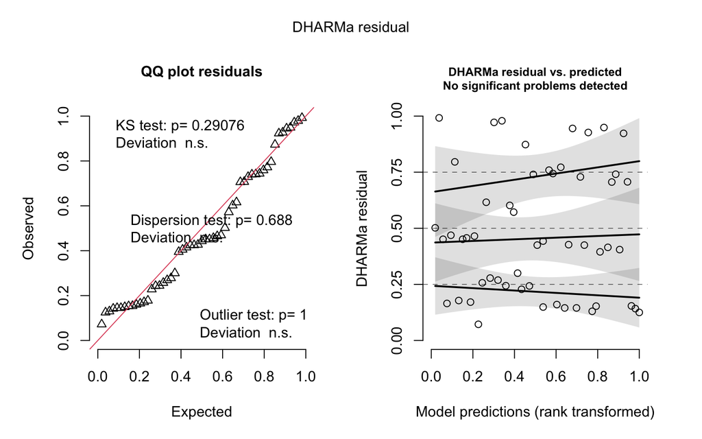

```r
sim_fig1g <- DHARMa::simulateResiduals(fig1g_lm, n = 1000, seed = DHARMA_SEED)
plot(sim_fig1g)
```

**Run DHARMa diagnostics**

```r
invisible(capture.output(
    fig1g_dharma_tests <- list(
        uniformity     = DHARMa::testUniformity(sim_fig1g, plot = FALSE),
        dispersion     = DHARMa::testDispersion(sim_fig1g, plot = FALSE),
        outliers = DHARMa::testOutliers(sim_fig1g, plot = FALSE)
    )
))

fig1g_dharma_tests %>%
    purrr::map_dfr(
        \(t) tibble(statistic = t$statistic, p.value = t$p.value),
        .id = "test"
    ) %>%
    mutate(across(where(is.numeric), \(x) signif(x, 3)), sig = sig_stars(p.value)) %>%
    minimal_tbl()
```

| test | statistic | p.value | sig |
| --- | --- | --- | --- |
| uniformity | 0.135 | 0.291 | ns |
| dispersion | 0.915 | 0.688 | ns |
| outliers | 0.000 | 1.000 | ns |

### Global F-test

Type III ANOVA on `progeny ~ heteroplasmy + brain`; the `heteroplasmy` term tests whether *in situ* heteroplasmy predicts progeny count once brain is held fixed.

**Type III ANOVA**

```r
fig1g_anova <- car::Anova(fig1g_lm, type = "III") %>%
    as.data.frame() %>%
    tibble::rownames_to_column("term") %>%
    rename(df = Df, F = `F value`, p.value = `Pr(>F)`)

fig1g_anova %>%
    mutate(across(where(is.numeric), \(x) signif(x, 3)), sig = sig_stars(p.value)) %>%
    sig_tbl()
```

| term | Sum Sq | df | F | p.value | sig |
| --- | --- | --- | --- | --- | --- |
| (Intercept) | 25.70000 | 1 | 19.60000 | 5.52e-05 | *** |
| het_pct | 0.00217 | 1 | 0.00166 | 9.68e-01 | ns |
| brain | 11.00000 | 3 | 2.79000 | 5.06e-02 | ns |
| Residuals | 63.00000 | 48 | NA | NA |  |

Heteroplasmy has no significant effect on progeny count once brain is accounted for ($F(1, 48) = 0.00166$, $p = 0.97$).

## Fig 1P: Mito-XhoI in heteroplasmic and homoplasmic NSC clones

EdU-positive progeny per NSC clone is compared in a 2 × 2 factorial of mitochondrially targeted transgene (`MitoGFP` control vs. `MitoXho1`) × mtDNA background (`Homoplasmic WT` vs. `Heteroplasmic`), one clone per row, with brain as the biological replicate.

The data are fit with a linear mixed-effects model:

`EdU ~ mito_type * background + (1 | brain_uid)`

Sum-to-zero contrasts are applied to both factors so that each Type III main effect is marginal to the interaction. `MitoXho1` is then compared to `MitoGFP` within each mtDNA background, with a multivariate-$t$ adjustment across the two comparisons.

**Load Fig 1P heteroplasmic-clone data and tabulate clones and brains per group**

```r
fig1p_df <- read_stat("fig_01p_heteroplasmic_clones.csv") %>%
    filter(!is.na(value)) %>%
    transmute(
        EdU        = value,
        mito_type  = factor(mito_type,        levels = c("MitoGFP", "MitoXho1")),
        background = factor(mtdna_background,  levels = c("Homoplasmic WT", "Heteroplasmic")),
        brain_uid  = factor(replicate_id)
    )

stopifnot(!anyNA(fig1p_df$mito_type), !anyNA(fig1p_df$background))

fig1p_df %>%
    group_by(mito_type, background) %>%
    summarise(
        n_clones = n(),
        n_brains = n_distinct(brain_uid),
        .groups  = "drop"
    ) %>%
    minimal_tbl()
```

| mito_type | background | n_clones | n_brains |
| --- | --- | --- | --- |
| MitoGFP | Homoplasmic WT | 53 | 6 |
| MitoGFP | Heteroplasmic | 37 | 15 |
| MitoXho1 | Homoplasmic WT | 55 | 8 |
| MitoXho1 | Heteroplasmic | 58 | 10 |

### Diagnostics

**Fit clone-level linear mixed-effects model**

```r
contrasts(fig1p_df$mito_type)  <- contr.sum(2)
contrasts(fig1p_df$background) <- contr.sum(2)

fig1p_lme <- lmerTest::lmer(
    EdU ~ mito_type * background + (1 | brain_uid),
    data = fig1p_df,
    REML = TRUE
)
summary(fig1p_lme)
```

**NoteModel fit diagnostics with DHARMa**

Scaled residuals from 1,000 simulations are tested for uniform distribution (Kolmogorov–Smirnov), dispersion, and an excess of outliers; all three should be non-significant for a well-fitting model.

**Run DHARMa diagnostics**

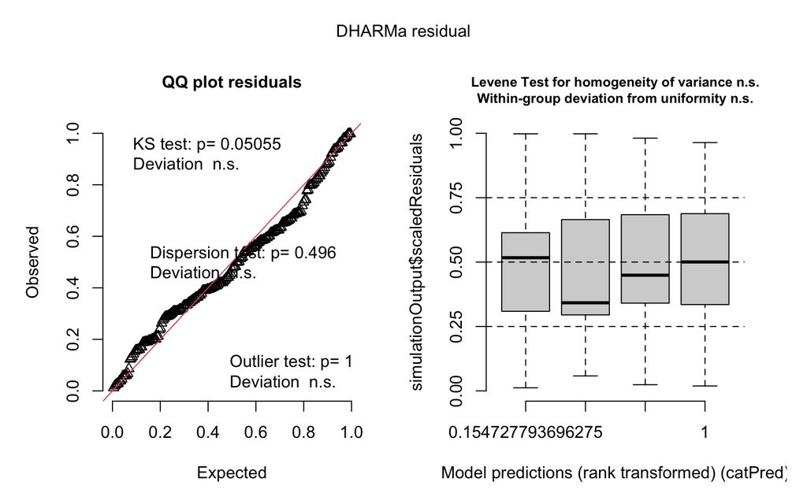

```r
sim_fig1p <- DHARMa::simulateResiduals(fig1p_lme, n = 1000, seed = DHARMA_SEED)
plot(sim_fig1p)
```

**Run DHARMa diagnostics**

```r
invisible(capture.output(
    fig1p_dharma_tests <- list(
        uniformity     = DHARMa::testUniformity(sim_fig1p, plot = FALSE),
        dispersion     = DHARMa::testDispersion(sim_fig1p, plot = FALSE),
        outliers = DHARMa::testOutliers(sim_fig1p, plot = FALSE)
    )
))

fig1p_dharma_tests %>%
    purrr::map_dfr(
        \(t) tibble(statistic = t$statistic, p.value = t$p.value),
        .id = "test"
    ) %>%
    mutate(across(where(is.numeric), \(x) signif(x, 3)), sig = sig_stars(p.value)) %>%
    minimal_tbl()
```

| test | statistic | p.value | sig |
| --- | --- | --- | --- |
| uniformity | 0.0952 | 0.0506 | ns |
| dispersion | 1.0600 | 0.4960 | ns |
| outliers | 0.0000 | 1.0000 | ns |

The uniformity (KS) test is borderline ($p = 0.051$) but not significant, and the dispersion and outlier tests are not flagged, so the Gaussian linear mixed-effects model is retained.

### Global F-test

Type III ANOVA (Satterthwaite degrees of freedom) on the two main effects and their interaction.

**Type III ANOVA**

```r
fig1p_anova <- anova(fig1p_lme, type = "III", ddf = "Satterthwaite") %>%
    as.data.frame()

fig1p_anova %>%
    tibble::rownames_to_column("term") %>%
    rename(df_num = NumDF, df_den = DenDF, F = `F value`, p.value = `Pr(>F)`) %>%
    mutate(across(where(is.numeric), \(x) signif(x, 3)), sig = sig_stars(p.value)) %>%
    sig_tbl()
```

| term | Sum Sq | Mean Sq | df_num | df_den | F | p.value | sig |
| --- | --- | --- | --- | --- | --- | --- | --- |
| mito_type | 4.430 | 4.430 | 1 | 31.8 | 1.780 | 0.191 | ns |
| background | 0.864 | 0.864 | 1 | 31.8 | 0.348 | 0.559 | ns |
| mito_type:background | 0.554 | 0.554 | 1 | 31.8 | 0.223 | 0.640 | ns |

None of the three terms reach significance: `background` ($F(1, 31.8) = 0.348$, $p = 0.56$), `mito_type` ($p = 0.19$), and their interaction ($p = 0.64$).

### MitoXho1 vs. MitoGFP, within each mtDNA background (multivariate-$t$ adjusted)

The two within-background comparisons are taken from the full `mito_type * background` estimated-marginal-means grid, with a multivariate-$t$ adjustment applied jointly across both.

**MitoXho1 vs. MitoGFP within each mtDNA background (multivariate-$t$ adjusted)**

```r
fig1p_em <- emmeans::emmeans(fig1p_lme, ~ mito_type * background)

fig1p_contrast_list <- list(
    "MitoXho1 - MitoGFP | Homoplasmic WT" = c(-1, 1,  0, 0),
    "MitoXho1 - MitoGFP | Heteroplasmic"  = c( 0, 0, -1, 1)
)

fig1p_contrast_results <- emmeans::contrast(
    fig1p_em,
    method = fig1p_contrast_list,
    adjust = "mvt"
) %>%
    summary(infer = c(TRUE, TRUE)) %>%
    as_tibble() %>%
    mutate(across(where(is.numeric), \(x) signif(x, 3)), sig = sig_stars(p.value))

fig1p_contrast_results %>%
    sig_tbl()
```

| contrast | estimate | SE | df | lower.CL | upper.CL | t.ratio | p.value | sig |
| --- | --- | --- | --- | --- | --- | --- | --- | --- |
| MitoXho1 - MitoGFP \| Homoplasmic WT | 1.11 | 0.95 | 27.8 | -1.13 | 3.35 | 1.17 | 0.437 | ns |
| MitoXho1 - MitoGFP \| Heteroplasmic | 0.53 | 0.78 | 36.8 | -1.28 | 2.35 | 0.68 | 0.748 | ns |

MitoXho1 does not significantly change EdU⁺ progeny count relative to MitoGFP in either the Homoplasmic WT background (1.11 progeny, $p = 0.44$) or the Heteroplasmic background (0.53 progeny, $p = 0.75$).

## Fig 3E & Supp Fig 7J: UCP1 / UCP2 rescue experiment

NSC mitotic index (% pH3⁺Dpn⁺ / Dpn⁺) is compared in a 3 × 3 factorial of RNAi condition (`Control`, `Complex I`, `Complex V`) × UCP expression (`GFP`, `UCP1`, `UCP2`), one brain per row (n = 6–13 per cell). The `UCP1` analysis is shown in Fig 3E and the `UCP2` analysis is shown in Supp Fig 7J; both are analysed here together. An interaction linear model is fit to the per-brain values:

`Mitotic_index ~ rnai * ucp`

**Load UCP1 / UCP2 rescue data and tabulate brains per cell**

```r
ucp_df <- read_stat("fig_03e_ucp_rescue.csv") %>%
    filter(!is.na(value)) %>%
    transmute(
        Mitotic_index = value,
        ucp  = factor(rescue_transgene, levels = c("GFP", "UCP1", "UCP2")),
        rnai = factor(rnai,             levels = c("Control", "Complex I", "Complex V"))
    )

# Explicit sum-to-zero coding is required for interpretable Type III main
# effects in this unbalanced factorial design.
contrasts(ucp_df$ucp)  <- contr.sum(nlevels(ucp_df$ucp))
contrasts(ucp_df$rnai) <- contr.sum(nlevels(ucp_df$rnai))

ucp_df %>%
    count(rnai, ucp, name = "n_brains") %>%
    minimal_tbl()
```

| rnai | ucp | n_brains |
| --- | --- | --- |
| Control | GFP | 10 |
| Control | UCP1 | 13 |
| Control | UCP2 | 12 |
| Complex I | GFP | 12 |
| Complex I | UCP1 | 12 |
| Complex I | UCP2 | 6 |
| Complex V | GFP | 12 |
| Complex V | UCP1 | 11 |
| Complex V | UCP2 | 6 |

### Diagnostics

**Fit interaction linear model (RNAi × UCP) on per-brain mitotic index**

```r
ucp_lm_raw <- lm(Mitotic_index ~ rnai * ucp, data = ucp_df)
summary(ucp_lm_raw)
```

**NoteModel fit diagnostics with DHARMa**

Scaled residuals from 1,000 simulations are tested for uniform distribution (Kolmogorov–Smirnov), dispersion, and an excess of outliers; all three should be non-significant for a well-fitting model.

**Run DHARMa diagnostics**

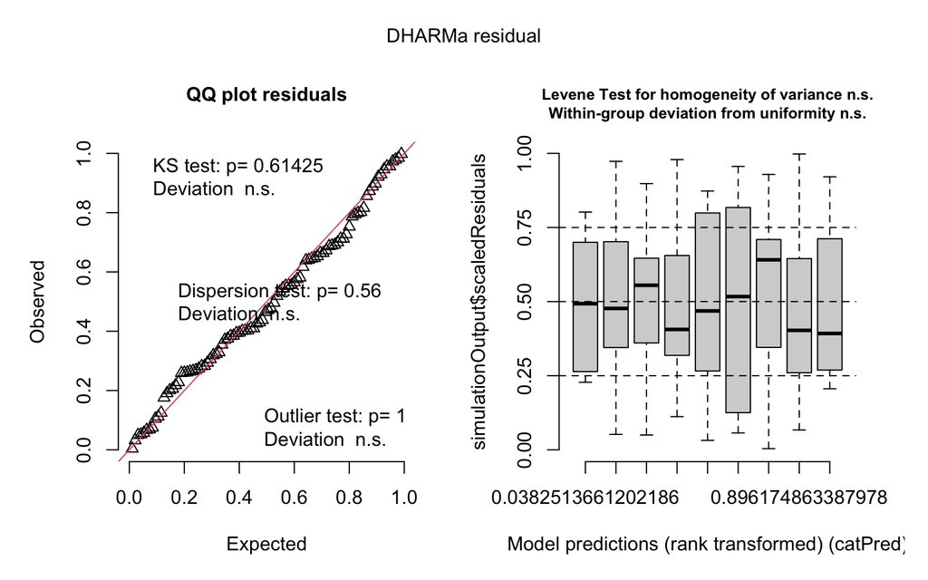

```r
sim_ucp_raw <- DHARMa::simulateResiduals(ucp_lm_raw, n = 1000, seed = DHARMA_SEED)
plot(sim_ucp_raw)
```

**Run DHARMa diagnostics**

```r
invisible(capture.output(
    ucp_dharma_tests <- list(
        uniformity     = DHARMa::testUniformity(sim_ucp_raw, plot = FALSE),
        dispersion     = DHARMa::testDispersion(sim_ucp_raw, plot = FALSE),
        outliers = DHARMa::testOutliers(sim_ucp_raw, plot = FALSE)
    )
))

ucp_dharma_tests %>%
    purrr::map_dfr(
        \(t) tibble(statistic = t$statistic, p.value = t$p.value),
        .id = "test"
    ) %>%
    mutate(across(where(is.numeric), \(x) signif(x, 3)), sig = sig_stars(p.value)) %>%
    minimal_tbl()
```

| test | statistic | p.value | sig |
| --- | --- | --- | --- |
| uniformity | 0.0781 | 0.614 | ns |
| dispersion | 0.9090 | 0.560 | ns |
| outliers | 0.0000 | 1.000 | ns |

### Global F-test

Type III ANOVA on `rnai * ucp`:

- `rnai`: whether RNAi knockdown affects mitotic index overall
- `ucp`: whether UCP expression alone has an effect
- `rnai:ucp`: whether the UCP effect differs across RNAi backgrounds

**Type III ANOVA**

```r
ucp_anova_type3 <- car::Anova(ucp_lm_raw, type = "III")

ucp_anova_type3 %>%
    as.data.frame() %>%
    tibble::rownames_to_column("term") %>%
    rename(df = Df, F = `F value`, p.value = `Pr(>F)`) %>%
    mutate(across(where(is.numeric), \(x) signif(x, 3)), sig = sig_stars(p.value)) %>%
    sig_tbl()
```

| term | Sum Sq | df | F | p.value | sig |
| --- | --- | --- | --- | --- | --- |
| (Intercept) | 35600 | 1 | 1540.00 | 0.0000 | *** |
| rnai | 1010 | 2 | 21.90 | 0.0000 | *** |
| ucp | 102 | 2 | 2.22 | 0.1150 | ns |
| rnai:ucp | 234 | 4 | 2.53 | 0.0465 | * |
| Residuals | 1960 | 85 | NA | NA |  |

The RNAi main effect was highly significant ($F(2, 85) = 21.9$, $p = 2.1 \times 10^{-8}$), with knockdown status accounting for the primary variation in mitotic index. The UCP main effect was not significant ($F(2, 85) = 2.22$, $p = 0.12$), but the interaction was significant ($F(4, 85) = 2.53$, $p = 0.046$), with the effect of UCP expression varying by RNAi background.

### Within-condition pairwise tests

`UCP1` and `UCP2` vs. their RNAi-matched `GFP` control within each RNAi condition (Dunnett’s test, multivariate-$t$ adjustment across the two comparisons per condition). Estimates are in percentage-point units.

**Marginal means and Dunnett’s contrasts (UCP vs. GFP, multivariate-$t$ adjusted)**

```r
ucp_emmeans <- emmeans::emmeans(ucp_lm_raw, ~ ucp | rnai)

ucp_contrasts <- emmeans::contrast(
    ucp_emmeans,
    method = "trt.vs.ctrl",
    ref    = "GFP",
    adjust = "mvt"
)

ucp_contrasts_summary <- summary(ucp_contrasts, infer = c(TRUE, TRUE))
```

| contrast | rnai | estimate | SE | df | lower.CL | upper.CL | t.ratio | p.value | sig |
| --- | --- | --- | --- | --- | --- | --- | --- | --- | --- |
| UCP1 - GFP | Control | 0.6890 | 2.02 | 85 | -3.84 | 5.22 | 0.3410 | 0.91600 | ns |
| UCP2 - GFP | Control | 0.0895 | 2.06 | 85 | -4.53 | 4.70 | 0.0435 | 0.99900 | ns |
| UCP1 - GFP | Complex I | -0.6220 | 1.96 | 85 | -5.05 | 3.81 | -0.3170 | 0.93300 | ns |
| UCP2 - GFP | Complex I | -0.7250 | 2.40 | 85 | -6.15 | 4.70 | -0.3020 | 0.93900 | ns |
| UCP1 - GFP | Complex V | 6.4000 | 2.01 | 85 | 1.87 | 10.90 | 3.1900 | 0.00392 | ** |
| UCP2 - GFP | Complex V | 7.4000 | 2.40 | 85 | 1.97 | 12.80 | 3.0800 | 0.00547 | ** |

Neither UCP had a significant effect in the `Control` or `Complex I` backgrounds (all $p \ge 0.92$). In the `Complex V` background, both `UCP1` ($+6.4$ pp, $p = 0.0039$) and `UCP2` ($+7.4$ pp, $p = 0.0055$) significantly increased mitotic index relative to `GFP`.

### Cross-condition effect comparisons

Following the significant `rnai:ucp` interaction, these difference-in-differences contrasts test whether the *magnitude* of the UCP rescue effect differs between the `Complex V` and `Complex I` backgrounds:

- `(UCP1 − GFP | Complex V) − (UCP1 − GFP | Complex I)`
- `(UCP2 − GFP | Complex V) − (UCP2 − GFP | Complex I)`

**UCP rescue effect: (multivariate-$t$ adjusted)**

```r
ucp_cell_emmeans <- emmeans::emmeans(ucp_lm_raw, ~ rnai * ucp)

ucp_all_interactions <- emmeans::contrast(
    ucp_cell_emmeans,
    interaction = c("revpairwise", "trt.vs.ctrl"),
    adjust = "none"
)

ucp_direct_interactions <- subset(
    ucp_all_interactions,
    rnai_revpairwise == "Complex V - Complex I"
)

ucp_direct_interactions_summary <- summary(
    ucp_direct_interactions,
    infer = c(TRUE, TRUE),
    adjust = "mvt"
)

ucp_direct_interactions_summary
```

| rnai_revpairwise | ucp_trt.vs.ctrl | estimate | SE | df | lower.CL | upper.CL | t.ratio | p.value | sig |
| --- | --- | --- | --- | --- | --- | --- | --- | --- | --- |
| Complex V - Complex I | UCP1 - GFP | 7.02 | 2.81 | 85 | 0.681 | 13.4 | 2.50 | 0.0274 | * |
| Complex V - Complex I | UCP2 - GFP | 8.13 | 3.40 | 85 | 0.447 | 15.8 | 2.39 | 0.0363 | * |

A positive estimate indicates a larger rescue effect in `Complex V`. Multivariate-*t* adjustment is applied across the two contrasts. Both contrasts were significant: the `UCP1` rescue effect was 7.02 percentage-points larger in `Complex V` than `Complex I` ($p = 0.027$), and the `UCP2` effect was 8.13 percentage-points larger ($p = 0.036$).

## Fig 3G: LbNox rescue experiment

NSC mitotic index (% pH3⁺Dpn⁺ / Dpn⁺) is compared in a 3 × 2 factorial of LbNox construct (`Control`, `nlsLbNox`, `mitoLbNox`) × RNAi background (`Control`, `Complex I`), one brain per row (n = 8–14 per cell). An interaction linear model is fit to the per-brain values:

`mitotic_index ~ rnai * lbnox`

**Load Fig 3G LbNox-rescue data and tabulate brains per cell**

```r
# Fig 3G analysing the Control and Complex I backgrounds
lbnox_df <- read_stat("fig_03g_lbnox_rescue.csv") %>%
    filter(!is.na(value), rnai %in% c("Control", "Complex I")) %>%
    transmute(
        mitotic_index = value,
        lbnox = factor(
            if_else(rescue_transgene == "None", "Control", rescue_transgene),
            levels = c("Control", "nlsLbNox", "mitoLbNox")
        ),
        rnai = factor(rnai, levels = c("Control", "Complex I"))
    )

# Sum-to-zero coding for interpretable Type III main effects in this
# unbalanced factorial design.
contrasts(lbnox_df$lbnox) <- contr.sum(nlevels(lbnox_df$lbnox))
contrasts(lbnox_df$rnai)  <- contr.sum(nlevels(lbnox_df$rnai))

lbnox_df %>%
    count(rnai, lbnox, name = "n_brains") %>%
    minimal_tbl()
```

| rnai | lbnox | n_brains |
| --- | --- | --- |
| Control | Control | 12 |
| Control | nlsLbNox | 8 |
| Control | mitoLbNox | 11 |
| Complex I | Control | 14 |
| Complex I | nlsLbNox | 8 |
| Complex I | mitoLbNox | 13 |

### Diagnostics

**Fit interaction linear model (RNAi × LbNox) on per-brain mitotic index**

```r
lbnox_lm <- lm(mitotic_index ~ rnai * lbnox, data = lbnox_df)
summary(lbnox_lm)
```

**NoteModel fit diagnostics with DHARMa**

Scaled residuals from 1,000 simulations are tested for uniform distribution (Kolmogorov–Smirnov), dispersion, and an excess of outliers; all three should be non-significant for a well-fitting model.

**Run DHARMa diagnostics**

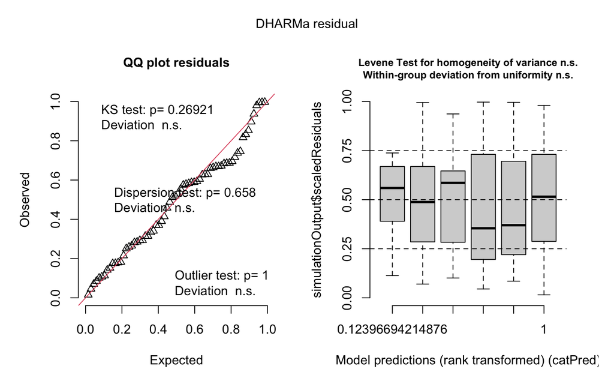

```r
sim_lbnox <- DHARMa::simulateResiduals(lbnox_lm, n = 1000, seed = DHARMA_SEED)
plot(sim_lbnox)
```

**Run DHARMa diagnostics**

```r
invisible(capture.output(
    lbnox_dharma_tests <- list(
        uniformity     = DHARMa::testUniformity(sim_lbnox, plot = FALSE),
        dispersion     = DHARMa::testDispersion(sim_lbnox, plot = FALSE),
        outliers = DHARMa::testOutliers(sim_lbnox, plot = FALSE)
    )
))

lbnox_dharma_tests %>%
    purrr::map_dfr(
        \(t) tibble(statistic = t$statistic, p.value = t$p.value),
        .id = "test"
    ) %>%
    mutate(across(where(is.numeric), \(x) signif(x, 3)), sig = sig_stars(p.value)) %>%
    minimal_tbl()
```

| test | statistic | p.value | sig |
| --- | --- | --- | --- |
| uniformity | 0.123 | 0.269 | ns |
| dispersion | 0.919 | 0.658 | ns |
| outliers | 0.000 | 1.000 | ns |

### Global F-test

Type III ANOVA on `rnai * lbnox`:

- `rnai`: whether RNAi knockdown affects mitotic index overall
- `lbnox`: whether LbNox expression alone has an effect
- `rnai:lbnox`: whether the LbNox effect differs across RNAi backgrounds

**Type III ANOVA**

```r
lbnox_anova_type3 <- car::Anova(lbnox_lm, type = "III")

lbnox_anova_type3 %>%
    as.data.frame() %>%
    tibble::rownames_to_column("term") %>%
    rename(df = Df, F = `F value`, p.value = `Pr(>F)`) %>%
    mutate(across(where(is.numeric), \(x) signif(x, 3)), sig = sig_stars(p.value)) %>%
    sig_tbl()
```

| term | Sum Sq | df | F | p.value | sig |
| --- | --- | --- | --- | --- | --- |
| (Intercept) | 27600.00 | 1 | 2030.000 | 0.00e+00 | *** |
| rnai | 295.00 | 1 | 21.700 | 1.82e-05 | *** |
| lbnox | 7.97 | 2 | 0.293 | 7.47e-01 | ns |
| rnai:lbnox | 428.00 | 2 | 15.700 | 3.20e-06 | *** |
| Residuals | 816.00 | 60 | NA | NA |  |

The `rnai` main effect was significant ($F(1, 60) = 21.7$, $p = 1.8 \times 10^{-5}$), but the `lbnox` main effect was not ($F(2, 60) = 0.293$, $p = 0.75$). The significant interaction ($F(2, 60) = 15.7$, $p = 3.2 \times 10^{-6}$) indicates that the effect of LbNox on mitotic index depends on the RNAi background.

### LbNox rescue within each RNAi background (Dunnett-style, multivariate-$t$ adjusted)

`nlsLbNox` and `mitoLbNox` vs. their RNAi-matched `Control` within each RNAi condition (Dunnett’s test, multivariate-$t$ adjustment across the two comparisons per condition). Estimates are in percentage-point units.

**Marginal means and Dunnett’s contrasts (LbNox vs. Control, multivariate-$t$ adjusted)**

```r
lbnox_emmeans <- emmeans::emmeans(lbnox_lm, ~ lbnox | rnai)

lbnox_contrasts <- emmeans::contrast(
    lbnox_emmeans,
    method = "trt.vs.ctrl",
    ref    = "Control",
    adjust = "mvt"
)

lbnox_contrasts_summary <- summary(lbnox_contrasts, infer = c(TRUE, TRUE))
```

| contrast | rnai | estimate | SE | df | lower.CL | upper.CL | t.ratio | p.value | sig |
| --- | --- | --- | --- | --- | --- | --- | --- | --- | --- |
| nlsLbNox - Control | Control | -4.76 | 1.68 | 60 | -8.58 | -0.935 | -2.83 | 0.012300 | * |
| mitoLbNox - Control | Control | -4.56 | 1.54 | 60 | -8.06 | -1.060 | -2.96 | 0.008460 | ** |
| nlsLbNox - Control | Complex I | 6.55 | 1.63 | 60 | 2.84 | 10.300 | 4.01 | 0.000337 | *** |
| mitoLbNox - Control | Complex I | 5.18 | 1.42 | 60 | 1.96 | 8.410 | 3.65 | 0.001080 | ** |

Within the `Control` RNAi background, both nlsLbNox (-4.76 pp, $p = 0.012$) and mitoLbNox (-4.56 pp, $p = 0.0085$) slightly reduced mitotic index relative to no-construct controls. Within the `Complex I` RNAi background, both constructs significantly increased mitotic index: nlsLbNox (6.55 pp, $p = 3.4 \times 10^{-4}$) and mitoLbNox (5.18 pp, $p = 0.0011$).

### Cross-condition effect comparisons

Following the significant `rnai:lbnox` interaction, these difference-in-differences contrasts test whether the *magnitude* of the LbNox rescue effect differs between the `Complex I` and `Control` RNAi backgrounds:

- `(nlsLbNox − Control | Complex I) − (nlsLbNox − Control | Control RNAi)`
- `(mitoLbNox − Control | Complex I) − (mitoLbNox − Control | Control RNAi)`

**LbNox rescue effect: difference-in-differences (multivariate-$t$ adjusted)**

```r
lbnox_cell_emmeans <- emmeans::emmeans(lbnox_lm, ~ rnai * lbnox)

lbnox_all_interactions <- emmeans::contrast(
    lbnox_cell_emmeans,
    interaction = c("revpairwise", "trt.vs.ctrl"),
    adjust = "none"
)

lbnox_direct_interactions <- subset(
    lbnox_all_interactions,
    rnai_revpairwise == "Complex I - Control"
)

lbnox_direct_interactions_summary <- summary(
    lbnox_direct_interactions,
    infer = c(TRUE, TRUE),
    adjust = "mvt"
)

lbnox_direct_interactions_summary
```

| rnai_revpairwise | lbnox_trt.vs.ctrl | estimate | SE | df | lower.CL | upper.CL | t.ratio | p.value | sig |
| --- | --- | --- | --- | --- | --- | --- | --- | --- | --- |
| Complex I - Control | nlsLbNox - Control | 11.30 | 2.35 | 60 | 5.98 | 16.6 | 4.82 | 2.00e-05 | *** |
| Complex I - Control | mitoLbNox - Control | 9.74 | 2.09 | 60 | 4.98 | 14.5 | 4.65 | 3.68e-05 | *** |

A positive estimate indicates a larger rescue effect in `Complex I` relative to `Control` RNAi. Both difference-in-differences contrasts were significant: the nlsLbNox rescue effect was 11.3 percentage-points larger in the Complex I background ($p = 2.0 \times 10^{-5}$), and the mitoLbNox effect was 9.74 percentage-points larger ($p = 3.7 \times 10^{-5}$).

## Fig 4C: Glial Inx2 KD and NSC proliferation

EdU-positive progeny per NSC clone is compared across three populations produced by a bipartite system that drives clonal Complex I RNAi in scattered NSCs (LexA/LexOp flip-out) while `repo-GAL4` drives the glial transgene in all glia of the same brain; one clone per row:

- `Luciferase`: Complex I RNAi NSC clones in control glia (Luciferase RNAi)
- `inx2`: Complex I RNAi NSC clones in Inx2-knockdown glia
- `inx2 (not clones)`: wild-type (non-flipped) NSCs in Inx2-knockdown glia, measured from the same brains as the `inx2` clones

`inx2` and `inx2 (not clones)` are measured from the *same two physical brains*; `Luciferase` is an independent set of three unrelated brains.

Because `inx2` and `inx2 (not clones)` are scored on the same brains, those two conditions share a random-effect group per brain, while the three `Luciferase` brains form their own groups:

`EdU ~ condition + (1 | brain_uid)`

The `inx2` vs. `inx2 (not clones)` comparison is therefore within-brain and well replicated at the clone level, whereas comparisons involving `Luciferase` are limited by the five independent brains available.

**Load Fig 4C inx2 data and tabulate clones and brains per condition**

```r
# `inx2` and `inx2 (not clones)` are scored on the same physical brains and
# share one `replicate_id`, which is used directly as the random-effect group.
inx2_df <- read_stat("fig_04c_inx2_edu.csv") %>%
    filter(!is.na(value)) %>%
    transmute(
        EdU       = value,
        condition = factor(genotype,
                           levels = c("Luciferase", "inx2", "inx2 (not clones)")),
        brain_uid = replicate_id
    )

inx2_df %>%
    group_by(condition) %>%
    summarise(
        n_clones = n(),
        n_brains = n_distinct(brain_uid),
        .groups  = "drop"
    ) %>%
    minimal_tbl()
```

| condition | n_clones | n_brains |
| --- | --- | --- |
| Luciferase | 17 | 3 |
| inx2 | 10 | 2 |
| inx2 (not clones) | 13 | 2 |

### Diagnostics

**Fit clone-level linear mixed-effects model**

```r
inx2_lme <- lmerTest::lmer(
    EdU ~ condition + (1 | brain_uid),
    data    = inx2_df,
    REML    = TRUE,
    control = lme4::lmerControl(optimizer = "bobyqa")
)

summary(inx2_lme)
```

**NoteModel fit diagnostics with DHARMa**

Scaled residuals from 1,000 simulations are tested for uniform distribution (Kolmogorov–Smirnov), dispersion, and an excess of outliers; all three should be non-significant for a well-fitting model.

**Run DHARMa diagnostics**

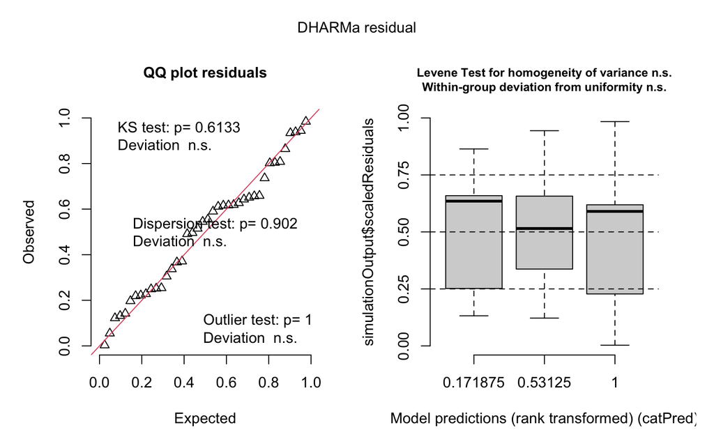

```r
sim_inx2 <- DHARMa::simulateResiduals(inx2_lme, n = 1000, seed = DHARMA_SEED)
plot(sim_inx2)
```

**Run DHARMa diagnostics**

```r
invisible(capture.output(
    inx2_dharma_tests <- list(
        uniformity     = DHARMa::testUniformity(sim_inx2, plot = FALSE),
        dispersion     = DHARMa::testDispersion(sim_inx2, plot = FALSE),
        outliers = DHARMa::testOutliers(sim_inx2, plot = FALSE)
    )
))

inx2_dharma_tests %>%
    purrr::map_dfr(
        \(t) tibble(statistic = t$statistic, p.value = t$p.value),
        .id = "test"
    ) %>%
    mutate(across(where(is.numeric), \(x) signif(x, 3)), sig = sig_stars(p.value)) %>%
    minimal_tbl()
```

| test | statistic | p.value | sig |
| --- | --- | --- | --- |
| uniformity | 0.116 | 0.613 | ns |
| dispersion | 0.961 | 0.902 | ns |
| outliers | 0.000 | 1.000 | ns |

**Variance-components table (between-brain vs. residual)**

```r
vc_inx2 <- as.data.frame(lme4::VarCorr(inx2_lme))
vc_inx2$pct <- round(100 * vc_inx2$vcov / sum(vc_inx2$vcov), 1)

vc_inx2[, c("grp", "vcov", "pct")] %>%
    minimal_tbl()
```

| grp | vcov | pct |
| --- | --- | --- |
| brain_uid | 0.1601377 | 8.6 |
| Residual | 1.7083202 | 91.4 |

### Global F-test

Type III ANOVA (Satterthwaite degrees of freedom) on the `condition` term, testing whether the three populations differ in EdU incorporation.

**Type III ANOVA**

```r
anova(inx2_lme, type = "III", ddf = "Satterthwaite") %>%
    as.data.frame() %>%
    tibble::rownames_to_column("term") %>%
    rename(df_num = NumDF, df_den = DenDF, F = `F value`, p.value = `Pr(>F)`) %>%
    mutate(across(where(is.numeric), \(x) signif(x, 3)), sig = sig_stars(p.value)) %>%
    sig_tbl()
```

| term | Sum Sq | Mean Sq | df_num | df_den | F | p.value | sig |
| --- | --- | --- | --- | --- | --- | --- | --- |
| condition | 26 | 13 | 2 | 3.28 | 7.6 | 0.0587 | ns |

### Inx2 KD effect on CI-deficient and WT NSCs (multivariate-$t$ adjusted)

Estimates are in EdU percentage points.

**Marginal means and the three inx2 contrasts (multivariate-$t$ adjusted)**

```r
inx2_em <- emmeans::emmeans(inx2_lme, specs = ~ condition)

inx2_contrast_list <- list(
    "inx2 - Luciferase"              = c(-1,  1,  0),
    "inx2 (not clones) - inx2"       = c( 0, -1,  1),
    "inx2 (not clones) - Luciferase" = c(-1,  0,  1)
)

inx2_contrast_results <- emmeans::contrast(inx2_em, method = inx2_contrast_list, adjust = "mvt") %>%
    summary(infer = c(TRUE, TRUE)) %>%
    as_tibble() %>%
    mutate(across(where(is.numeric), \(x) signif(x, 3)),
           sig = sig_stars(p.value))

inx2_contrast_results %>%
    sig_tbl()
```

| contrast | estimate | SE | df | lower.CL | upper.CL | t.ratio | p.value | sig |
| --- | --- | --- | --- | --- | --- | --- | --- | --- |
| inx2 - Luciferase | -2.060 | 0.668 | 3.86 | -4.440 | 0.315 | -3.090 | 0.07620 | ns |
| inx2 (not clones) - inx2 | 1.940 | 0.559 | 35.10 | 0.572 | 3.300 | 3.470 | 0.00388 | ** |
| inx2 (not clones) - Luciferase | -0.126 | 0.634 | 3.19 | -2.780 | 2.520 | -0.199 | 0.97800 | ns |

The `inx2 (not clones) - inx2` contrast is a within-brain comparison (both measured from the same 2 physical brains) and is well powered (df ≈ 35); contrasts against `Luciferase` are limited by the 5 independent physical brains available (df ≈ 4) and do not reach significance. WT-neighbor NSCs (`inx2 (not clones)`) are statistically indistinguishable from the unrelated WT baseline (`Luciferase`), while the clonal CI-RNAi NSCs (`inx2`) proliferate significantly less than their WT neighbors in the same brain.

## Fig 4D & 4L: Glial RNAi screen (pooled analysis, joint BH-FDR)

EdU-positive progeny per NSC clone is compared across a pooled set of glial RNAi knockdowns (the transmembrane-transporter and metabolic-enzyme screens, Fig 4D and Fig 4L, plus the cortex-glia and glial-OxPhos screen conditions). Each knockdown is compared against the shared reference controls `mCherry x Luciferase` (wild-type proliferation) and `ND42 x Luciferase` (Complex I dysfunction baseline), one clone per row.

Brains are the biological replicate and the model is:

`EdU ~ condition + (1 | brain_uid)`

Each knockdown is compared to `ND42 x Luciferase`, with a Benjamini-Hochberg FDR correction applied jointly across all knockdown contrasts.

**Load the pooled glial RNAi screen data**

```r
CTRL_COMB <- "mCherry x Luciferase"
REF_COMB  <- "ND42 x Luciferase"

combined_raw <- read_stat("edu_glial_screen.csv") %>%
    filter(in_combined_screen, !is.na(value)) %>%
    transmute(
        EdU         = value,
        genotype    = genotype,
        date        = collection_date,
        brain_uid   = replicate_id,
        figure      = manuscript_panel,
        screen_type
    )
```

### Data Summary

**Summarise the screen: clones, conditions, knockdowns, brains, dates**

```r
combined_raw %>%
    summarise(
        n_clone_rows = n(),
        n_conditions = n_distinct(genotype),
        n_knockdowns = n_distinct(genotype[screen_type != "control"]),
        n_brains = n_distinct(brain_uid),
        n_dates = n_distinct(date)
    ) %>%
    minimal_tbl()
```

| n_clone_rows | n_conditions | n_knockdowns | n_brains | n_dates |
| --- | --- | --- | --- | --- |
| 1413 | 53 | 51 | 321 | 39 |

### Statistical analysis

**List the screen knockdowns and build the condition factor**

```r
screen_kds <- combined_raw %>%
    filter(screen_type != "control") %>%
    pull(genotype) %>%
    unique() %>%
    sort()
n_screen_kds <- length(screen_kds)

combined_model_data <- combined_raw %>%
    mutate(
        condition = factor(
            genotype,
            levels = c(CTRL_COMB, REF_COMB, screen_kds)
        )
    )
```

**NoteReplication counts per knockdown**

| figure | screen_type | condition | n_clone_rows | n_brains | n_dates |
| --- | --- | --- | --- | --- | --- |
| Fig_4D | transporter | ND42 x aralar1 | 46 | 11 | 3 |
| Fig_4D | transporter | ND42 x Balat | 26 | 7 | 2 |
| Fig_4D | transporter | ND42 x CD98hc | 4 | 2 | 1 |
| Fig_4D | transporter | ND42 x CG10019 | 16 | 3 | 1 |
| Fig_4D | transporter | ND42 x CG12773 | 20 | 4 | 1 |
| Fig_4D | transporter | ND42 x CG13384 | 20 | 4 | 2 |
| Fig_4D | transporter | ND42 x CG1628 | 19 | 6 | 2 |
| Fig_4D | transporter | ND42 x CG43693 | 24 | 5 | 3 |
| Fig_4D | transporter | ND42 x CG4476 | 17 | 4 | 1 |
| Fig_4D | transporter | ND42 x CG5535 | 35 | 9 | 2 |
| Fig_4D | transporter | ND42 x CG8468 | 19 | 4 | 2 |
| Fig_4D | transporter | ND42 x chaski | 21 | 4 | 2 |
| Fig_4D | transporter | ND42 x dmGlut | 50 | 7 | 1 |
| Fig_4D | transporter | ND42 x Eaat1 | 28 | 6 | 2 |
| Fig_4D | transporter | ND42 x Eaat2 | 26 | 5 | 3 |
| Fig_4D | transporter | ND42 x fatp | 9 | 3 | 1 |
| Fig_4D | transporter | ND42 x GC1 | 19 | 4 | 2 |
| Fig_4D | transporter | ND42 x hrm | 32 | 6 | 3 |
| Fig_4D | transporter | ND42 x Indy | 12 | 4 | 2 |
| Fig_4D | transporter | ND42 x kcc | 24 | 5 | 2 |
| Fig_4D | transporter | ND42 x Mct1 | 25 | 5 | 2 |
| Fig_4D | transporter | ND42 x Mpc1 | 22 | 5 | 1 |
| Fig_4D | transporter | ND42 x out | 40 | 6 | 1 |
| Fig_4D | transporter | ND42 x path | 40 | 10 | 6 |
| Fig_4D | transporter | ND42 x prestin | 20 | 4 | 2 |
| Fig_4D | transporter | ND42 x sbm | 43 | 8 | 2 |
| Fig_4D | transporter | ND42 x Sfxn1-3 | 18 | 5 | 1 |
| Fig_4D | transporter | ND42 x Slif | 30 | 7 | 1 |
| Fig_4D | transporter | ND42 x Sln | 27 | 5 | 2 |
| Fig_4L | enzyme | ND42 x Acly | 9 | 3 | 2 |
| Fig_4L | enzyme | ND42 x Alat | 13 | 3 | 1 |
| Fig_4L | enzyme | ND42 x Gdh | 30 | 7 | 1 |
| Fig_4L | enzyme | ND42 x GLS | 4 | 1 | 1 |
| Fig_4L | enzyme | ND42 x GOT1 | 18 | 4 | 1 |
| Fig_4L | enzyme | ND42 x GOT2 | 4 | 1 | 1 |
| Fig_4L | enzyme | ND42 x GS2 | 22 | 5 | 3 |
| Fig_4L | enzyme | ND42 x Idh | 8 | 2 | 1 |
| Fig_4L | enzyme | ND42 x mAcon1 | 21 | 4 | 1 |
| Fig_4L | enzyme | ND42 x Mdh1 | 17 | 3 | 2 |
| Fig_4L | enzyme | ND42 x Mdh2 | 8 | 2 | 2 |
| Fig_4L | enzyme | ND42 x Pcb | 11 | 2 | 1 |
| Fig_4L | enzyme | ND42 x PyK | 24 | 7 | 2 |
| Fig_4L | enzyme | ND42 x SdhD | 52 | 15 | 3 |
| Fig_S8D | enzyme | ND42 x hbs | 3 | 1 | 1 |
| Fig_S8D | enzyme | ND42 x sns | 50 | 13 | 3 |
| Fig_S8D | enzyme | ND42 x WASp | 43 | 10 | 3 |
| Fig_S9A | enzyme | ND42 x ATPsynO | 15 | 5 | 1 |
| Fig_S9A | enzyme | ND42 x DGAT1 | 32 | 8 | 3 |
| Fig_S9A | enzyme | ND42 x Lsd2 | 13 | 4 | 1 |
| Fig_S9A | enzyme | ND42 x ND42 | 12 | 3 | 1 |
| Fig_S9A | enzyme | ND42 x Pld | 23 | 8 | 2 |

### Diagnostics

**Fit combined-screen no-date model**

```r
combined_screen_model <- lmerTest::lmer(
    EdU ~ condition + (1 | brain_uid),
    data = combined_model_data,
    REML = TRUE,
    control = lme4::lmerControl(
        optimizer = "bobyqa",
        optCtrl = list(maxfun = 200000)
    )
)

summary(combined_screen_model)
```

**NoteModel fit diagnostics with DHARMa**

Scaled residuals from 1,000 simulations are tested for uniform distribution (Kolmogorov–Smirnov), dispersion, and an excess of outliers; all three should be non-significant for a well-fitting model.

**Run DHARMa diagnostics**

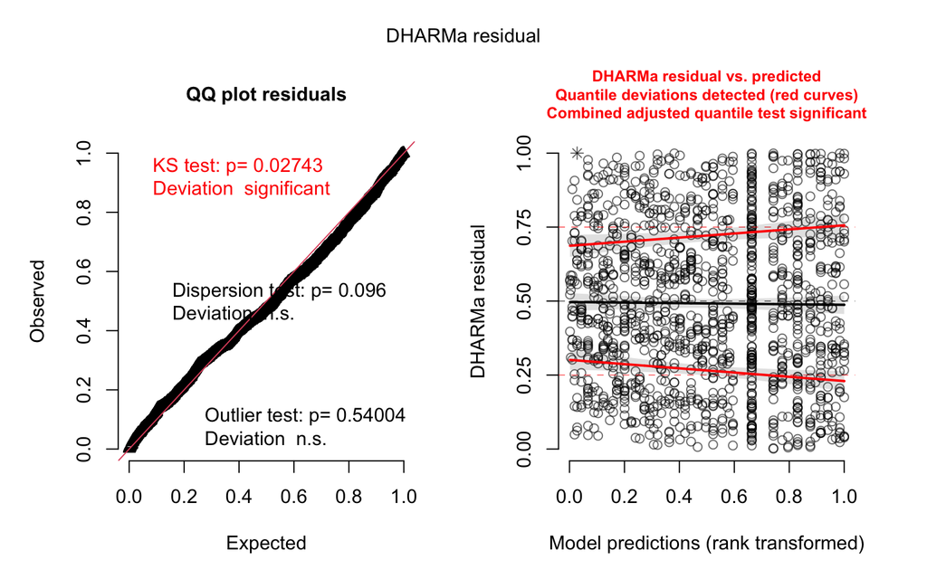

```r
sim_combined <- DHARMa::simulateResiduals(
    combined_screen_model,
    n = 1000,
    seed = DHARMA_SEED
)
plot(sim_combined)
```

**Run DHARMa diagnostics**

```r
invisible(capture.output(
    combined_dharma_tests <- list(
        uniformity     = DHARMa::testUniformity(sim_combined, plot = FALSE),
        dispersion     = DHARMa::testDispersion(sim_combined, plot = FALSE),
        outliers = DHARMa::testOutliers(sim_combined, plot = FALSE)
    )
))

combined_dharma_tests %>%
    purrr::map_dfr(
        \(t) tibble(statistic = t$statistic, p.value = t$p.value),
        .id = "test"
    ) %>%
    mutate(across(where(is.numeric), \(x) signif(x, 3)), sig = sig_stars(p.value)) %>%
    minimal_tbl()
```

| test | statistic | p.value | sig |
| --- | --- | --- | --- |
| uniformity | 0.039 | 0.0274 | * |
| dispersion | 1.060 | 0.0960 | ns |
| outliers | 1.000 | 0.5400 | ns |

**Variance-components table (between-brain vs. residual)**

```r
vc_combined <- as.data.frame(lme4::VarCorr(combined_screen_model))
vc_combined$pct <- round(100 * vc_combined$vcov / sum(vc_combined$vcov), 1)

vc_combined[, c("grp", "vcov", "pct")] %>%
    minimal_tbl()
```

| grp | vcov | pct |
| --- | --- | --- |
| brain_uid | 0.8538318 | 24.5 |
| Residual | 2.6313050 | 75.5 |

### Global F-test

Type III ANOVA F-test; the `condition` term tests whether any knockdown differs from the reference across the screen.

**Type III ANOVA**

```r
combined_anova_res <- anova(combined_screen_model, type = "III", ddf = "Satterthwaite") %>%
    as.data.frame() %>%
    tibble::rownames_to_column("term") %>%
    rename(df_num = NumDF, df_den = DenDF, F = `F value`, p.value = `Pr(>F)`)

combined_anova_res %>%
    mutate(across(where(is.numeric), \(x) signif(x, 3)), sig = sig_stars(p.value)) %>%
    sig_tbl()
```

| term | Sum Sq | Mean Sq | df_num | df_den | F | p.value | sig |
| --- | --- | --- | --- | --- | --- | --- | --- |
| condition | 469 | 9.01 | 52 | 242 | 3.43 | 0 | *** |

The `condition` term was highly significant ($F(52, 242) = 3.43$, $p = 6.4 \times 10^{-11}$); at least one knockdown condition differs from the CI dysfunction baseline.

### Each knockdown vs. ND42 x Luciferase (joint BH-FDR)

Estimates are in EdU percentage points. The phenotype contrast (`ND42 x Luciferase` vs. `mCherry x Luciferase`) is a single comparison and is not corrected. Each knockdown is compared to `ND42 x Luciferase`, with a Benjamini-Hochberg FDR correction applied jointly across all 51 knockdown contrasts.

**Estimated marginal means per condition**

```r
combined_emmeans <- emmeans::emmeans(combined_screen_model, specs = ~ condition)
summary(combined_emmeans)
```

**CI dysfunction vs. wild-type phenotype contrast (uncorrected)**

```r
phenotype_contrast_comb <- emmeans::contrast(
    combined_emmeans,
    method = list(
        "ND42 x Luciferase - mCherry x Luciferase" =
            c(-1, 1, rep(0, length(screen_kds)))
    ),
    adjust = "none"
)

phenotype_contrast_summary <- summary(phenotype_contrast_comb, infer = c(TRUE, TRUE)) %>%
    as_tibble()

phenotype_contrast_summary %>%
    mutate(across(where(is.numeric), \(x) signif(x, 3)), sig = sig_stars(p.value)) %>%
    sig_tbl()
```

| contrast | estimate | SE | df | lower.CL | upper.CL | t.ratio | p.value | sig |
| --- | --- | --- | --- | --- | --- | --- | --- | --- |
| ND42 x Luciferase - mCherry x Luciferase | -0.467 | 0.365 | 237 | -1.19 | 0.252 | -1.28 | 0.202 | ns |

The CI dysfunction baseline (`ND42 x Luciferase`) showed a 0.467 EdU pp reduction relative to wild-type ($t(237) = -1.28$, $p = 0.2$).

**Each knockdown vs. ND42 x Luciferase; joint Benjamini-Hochberg FDR across knockdowns**

```r
combined_em_screen <- combined_emmeans[
    match(c(REF_COMB, screen_kds), combined_emmeans@grid$condition)
]

combined_screen_contrasts <- summary(
    emmeans::contrast(
        combined_em_screen,
        method = "trt.vs.ctrl",
        ref = 1,
        adjust = "none"
    ),
    infer = c(TRUE, TRUE)
) %>%
    as_tibble() %>%
    mutate(
        gene = as.character(contrast) %>%
            str_remove(fixed(paste0(" - ", REF_COMB))) %>%
            str_remove(fixed(paste0(" / ", REF_COMB))) %>%
            str_replace("^\\((.+)\\)$", "\\1"),
        p.fdr = p.adjust(p.value, method = "BH"),
        sig_label = sig_stars(p.fdr, na_as = NA_character_)
    )

genotype_figure <- combined_raw %>%
    filter(screen_type != "control") %>%
    distinct(genotype, figure, screen_type)

combined_results <- combined_screen_contrasts %>%
    left_join(genotype_figure, by = c("gene" = "genotype")) %>%
    select(
        figure,
        screen_type,
        gene,
        estimate,
        SE,
        df,
        lower.CL,
        upper.CL,
        t.ratio,
        p.value,
        p.fdr,
        sig_label
    ) %>%
    arrange(figure, p.fdr)

combined_results_display <- combined_results %>%
    mutate(across(where(is.numeric), \(x) signif(x, 3)))

reactable::reactable(
    combined_results_display,
    elementId     = "combined_screen_table",
    filterable    = TRUE,
    pagination    = FALSE,
    bordered      = TRUE,
    compact       = TRUE,
    highlight     = TRUE,
    defaultSorted = "p.fdr",
    theme = reactable::reactableTheme(
        borderColor    = "#dee2e6",
        stripedColor   = "#f8f9fa",
        highlightColor = "#f0f0f0",
        cellPadding    = "6px 8px",
        style          = list(fontSize = "0.9rem", fontFamily = "inherit")
    ),
    rowStyle = function(index) {
        sig   <- combined_results_display$sig_label[index]
        color <- switch(sig, "***" = "#c8e6c9", "**" = "#def0de", "*" = "#f0faf0", NA)
        if (!is.na(color)) list(backgroundColor = color) else list()
    },
    defaultColDef = reactable::colDef(
        header = function(value, name) {
            htmltools::tagList(
                value,
                htmltools::tags$span(
                    "⇅",
                    title = "Click to sort",
                    style = "margin-left: 4px; color: #999; font-size: 0.75em; font-weight: normal;"
                )
            )
        }
    ),
    columns = list(
        figure      = reactable::colDef(minWidth = 70),
        screen_type = reactable::colDef(
            name     = "Type",
            minWidth = 90,
            filterInput = function(values, name) {
                htmltools::tags$select(
                    style = "width: 100%; max-width: 100%; box-sizing: border-box;",
                    onchange = sprintf(
                        "Reactable.setFilter('combined_screen_table', '%s', event.target.value || undefined)",
                        name
                    ),
                    htmltools::tags$option(value = "", "All"),
                    lapply(sort(unique(values)), htmltools::tags$option)
                )
            }
        ),
        gene      = reactable::colDef(minWidth = 145),
        estimate  = reactable::colDef(minWidth = 85),
        SE        = reactable::colDef(minWidth = 48),
        df        = reactable::colDef(minWidth = 48),
        lower.CL  = reactable::colDef(name = "Lower", minWidth = 65),
        upper.CL  = reactable::colDef(name = "Upper", minWidth = 65),
        t.ratio   = reactable::colDef(minWidth = 54),
        p.value   = reactable::colDef(minWidth = 70),
        p.fdr     = reactable::colDef(minWidth = 70),
        sig_label = reactable::colDef(name = "Sig.",  minWidth = 55)
    )
)
```

| figure | Type | gene | estimate | SE | df | Lower | Upper | t.ratio | p.value | p.fdr | Sig. |
| --- | --- | --- | --- | --- | --- | --- | --- | --- | --- | --- | --- |
| Fig_4D | transporter | ND42 x path | -1.96 | 0.459 | 260 | -2.86 | -1.05 | -4.27 | 2.77e-05 | 0.00141 | ** |
| Fig_4D | transporter | ND42 x Eaat1 | -2.02 | 0.535 | 243 | -3.08 | -0.968 | -3.78 | 0.000198 | 0.00337 | ** |
| Fig_4D | transporter | ND42 x hrm | -1.75 | 0.518 | 220 | -2.77 | -0.728 | -3.38 | 0.000869 | 0.0079 | ** |
| Fig_4D | transporter | ND42 x CD98hc | -3.57 | 1.09 | 478 | -5.72 | -1.42 | -3.26 | 0.00118 | 0.00857 | ** |
| Fig_4D | transporter | ND42 x Mct1 | -1.66 | 0.566 | 228 | -2.77 | -0.54 | -2.92 | 0.0038 | 0.0228 | * |
| Fig_4D | transporter | ND42 x Indy | -1.74 | 0.711 | 345 | -3.14 | -0.344 | -2.45 | 0.0148 | 0.0538 | ns |
| Fig_4D | transporter | ND42 x CG43693 | 1.09 | 0.57 | 234 | -0.0372 | 2.21 | 1.9 | 0.058 | 0.174 | ns |
| Fig_4D | transporter | ND42 x CG8468 | -1.09 | 0.642 | 240 | -2.35 | 0.18 | -1.69 | 0.0924 | 0.244 | ns |
| Fig_4D | transporter | ND42 x Slif | -0.855 | 0.507 | 254 | -1.85 | 0.143 | -1.69 | 0.0927 | 0.244 | ns |
| Fig_4D | transporter | ND42 x CG4476 | 1.02 | 0.663 | 248 | -0.284 | 2.33 | 1.54 | 0.125 | 0.302 | ns |

[output cut: 41 more lines]

13 of 51 knockdowns reached BH-FDR < 0.05 relative to the CI dysfunction baseline.

## Fig 4K: Eaat1 transporter rescue experiment

EdU-positive progeny per NSC clone is compared across genotypes that manipulate glial Eaat1 and NSC RNAi independently (two UAS-driver systems), one clone per row, with brain as the biological replicate. The genotypes form two panels:

- **Left panel (NSC control RNAi):** `mCherry x Luciferase` (NSC ctrl, glia ctrl) and `mCherry x Eaat1` (NSC ctrl, glia Eaat1 KD).
- **Right panel (NSC Complex I KD):** `ND42 x Luciferase` (NSC ND42 KD, glia ctrl), `ND42 x Eaat1` (NSC ND42 KD, glia Eaat1 KD), and `ND42 x Eaat1 RNAi_Eaat2GFP` (NSC ND42 KD, glia Eaat1 KD + UAS-Eaat2 rescue).

Each panel has its own model. The left panel is fit with a clone-level linear mixed-effects model with brain as a random intercept, `EdU ~ condition + (1 | brain_uid)`. The right panel is fit with a generalized least-squares model on the per-brain mean EdU counts with a condition-specific variance, `gls(mean_EdU ~ condition, weights = varIdent(form = ~ 1 | condition))`, giving each condition its own between-brain variance.

Two comparisons, specified a priori from the experimental design, are tested:

1. Eaat1 KD specificity (left panel): `mCherry x Eaat1` vs `mCherry x Luciferase`: Does glial Eaat1 KD alone affect NSC proliferation?
2. CI dysfunction and Eaat2-GFP rescue (right panel): three related comparisons, tested together with a joint multiplicity adjustment:
   - `ND42 x Eaat1` vs `ND42 x Luciferase`: Does Eaat1 KD worsen CI dysfunction?
   - `ND42 x Eaat1 RNAi_Eaat2GFP` vs `ND42 x Eaat1`: Does Eaat2 rescue the Eaat1 KD effect?
   - `ND42 x Eaat1 RNAi_Eaat2GFP` vs `ND42 x Luciferase`: Is proliferation restored to the CI-only level?

**Load Fig 4K Eaat1 data and tabulate clones and brains per condition**

```r
LUC_WT_4K     <- "mCherry x Luciferase"
EAAT1_WT_4K   <- "mCherry x Eaat1"
LUC_CI_4K     <- "ND42 x Luciferase"
EAAT1_CI_4K  <- "ND42 x Eaat1"
EAAT1_RESCUE_4K <- "ND42 x Eaat1 RNAi_Eaat2GFP"

eaat1_left_conditions  <- c(LUC_WT_4K, EAAT1_WT_4K)
eaat1_right_conditions <- c(LUC_CI_4K, EAAT1_CI_4K, EAAT1_RESCUE_4K)
eaat1_all_conditions   <- c(eaat1_left_conditions, eaat1_right_conditions)

eaat1_df <- read_stat("edu_glial_screen.csv") %>%
    filter(!is.na(value), genotype %in% eaat1_all_conditions) %>%
    transmute(
        EdU       = value,
        genotype  = genotype,
        date      = collection_date,
        brain_uid = replicate_id,
        condition = factor(genotype, levels = eaat1_all_conditions)
    )

eaat1_left_df <- eaat1_df %>%
    filter(genotype %in% eaat1_left_conditions) %>%
    mutate(condition = factor(genotype, levels = eaat1_left_conditions))

eaat1_right_df <- eaat1_df %>%
    filter(genotype %in% eaat1_right_conditions) %>%
    mutate(condition = factor(genotype, levels = eaat1_right_conditions))

eaat1_df %>%
    group_by(condition) %>%
    summarise(
        n_clones      = n(),
        n_brains      = n_distinct(brain_uid),
        n_dates       = n_distinct(date),
        .groups       = "drop"
    ) %>%
    minimal_tbl()
```

| condition | n_clones | n_brains | n_dates |
| --- | --- | --- | --- |
| mCherry x Luciferase | 78 | 16 | 4 |
| mCherry x Eaat1 | 16 | 4 | 3 |
| ND42 x Luciferase | 171 | 36 | 11 |
| ND42 x Eaat1 | 28 | 6 | 2 |
| ND42 x Eaat1 RNAi_Eaat2GFP | 23 | 6 | 2 |

### Diagnostics

**Fit left-panel LME and right-panel brain-mean GLS**

```r
eaat1_left_model <- lmerTest::lmer(
    EdU ~ condition + (1 | brain_uid),
    data = eaat1_left_df,
    REML = TRUE
)

eaat1_brain_means <- eaat1_df %>%
    group_by(condition, brain_uid) %>%
    summarise(mean_EdU = mean(EdU), .groups = "drop")

eaat1_right_brain_means <- eaat1_brain_means %>%
    filter(condition %in% eaat1_right_conditions) %>%
    mutate(condition = factor(condition, levels = eaat1_right_conditions))

eaat1_right_gls <- nlme::gls(
    mean_EdU ~ condition,
    weights = nlme::varIdent(form = ~1 | condition),
    data    = eaat1_right_brain_means,
    method  = "REML"
)

summary(eaat1_left_model)
summary(eaat1_right_gls)
```

**NoteRight panel: raw between-brain variance heterogeneity (Brown–Forsythe test)**

A Brown–Forsythe test (Levene’s test centred on the median) on the per-brain means quantifies the between-condition variance heterogeneity that motivates the heteroscedastic GLS.

**Run Brown-Forsythe test on raw brain means**

```r
eaat1_right_brain_means %>%
    group_by(condition) %>%
    summarise(n_brains = n(), sd = signif(sd(mean_EdU), 3), .groups = "drop") %>%
    minimal_tbl()
```

| condition | n_brains | sd |
| --- | --- | --- |
| ND42 x Luciferase | 36 | 1.430 |
| ND42 x Eaat1 | 6 | 0.488 |
| ND42 x Eaat1 RNAi_Eaat2GFP | 6 | 0.328 |

**Run Brown-Forsythe test on raw brain means**

```r
eaat1_right_raw_levene <- car::leveneTest(
    mean_EdU ~ condition,
    data   = eaat1_right_brain_means,
    center = "median"
)

tibble(
    test      = "Brown-Forsythe (raw brain means)",
    statistic = signif(eaat1_right_raw_levene$`F value`[1], 3),
    p.value   = signif(eaat1_right_raw_levene$`Pr(>F)`[1], 3)
) %>%
    mutate(sig = sig_stars(p.value)) %>%
    minimal_tbl()
```

| test | statistic | p.value | sig |
| --- | --- | --- | --- |
| Brown-Forsythe (raw brain means) | 4.2 | 0.0212 | * |

**NoteLeft panel: model fit diagnostics with DHARMa**

Scaled residuals from 1,000 simulations are tested for uniform distribution (Kolmogorov–Smirnov), dispersion, and an excess of outliers; all three should be non-significant for a well-fitting model.

**Run DHARMa diagnostics**

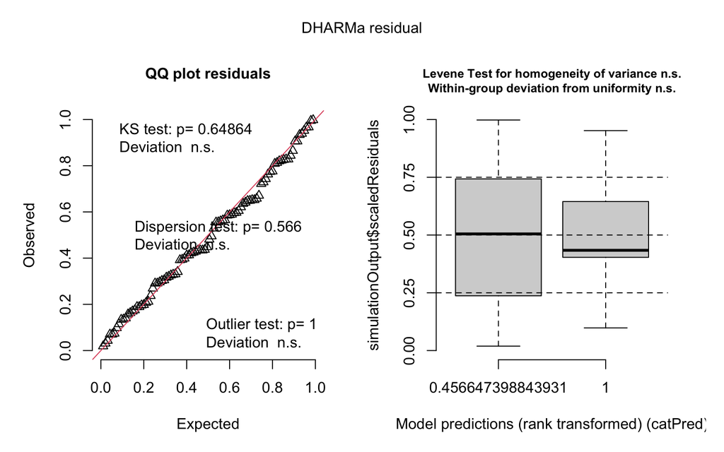

```r
sim_eaat1_left <- DHARMa::simulateResiduals(eaat1_left_model, n = 1000, seed = DHARMA_SEED)
plot(sim_eaat1_left)
```

**Run DHARMa diagnostics**

```r
invisible(capture.output(
    eaat1_dharma_tests <- list(
        left_uniformity     = DHARMa::testUniformity(sim_eaat1_left, plot = FALSE),
        left_dispersion     = DHARMa::testDispersion(sim_eaat1_left, plot = FALSE),
        left_outliers = DHARMa::testOutliers(sim_eaat1_left, plot = FALSE)
    )
))

eaat1_dharma_tests %>%
    purrr::map_dfr(
        \(t) tibble(statistic = t$statistic, p.value = t$p.value),
        .id = "test"
    ) %>%
    mutate(across(where(is.numeric), \(x) signif(x, 3)), sig = sig_stars(p.value)) %>%
    minimal_tbl()
```

| test | statistic | p.value | sig |
| --- | --- | --- | --- |
| left_uniformity | 0.076 | 0.649 | ns |
| left_dispersion | 1.080 | 0.566 | ns |
| left_outliers | 0.000 | 1.000 | ns |

**NoteRight panel: normalized-residual diagnostics (DHARMa does not support `gls` objects)**

**Normalised-residual normality and homogeneity checks for the GLS**

```r
eaat1_right_gls_resid <- resid(eaat1_right_gls, type = "normalized")
eaat1_right_gls_levene <- car::leveneTest(
    eaat1_right_gls_resid ~ eaat1_right_brain_means$condition,
    center = "median"
)

tibble(
    test      = c("Shapiro-Wilk (normality)", "Levene (homogeneity by condition)"),
    statistic = c(
        signif(shapiro.test(eaat1_right_gls_resid)$statistic, 3),
        signif(eaat1_right_gls_levene$`F value`[1], 3)
    ),
    p.value = c(
        signif(shapiro.test(eaat1_right_gls_resid)$p.value, 3),
        signif(eaat1_right_gls_levene$`Pr(>F)`[1], 3)
    )
) %>%
    mutate(sig = sig_stars(p.value)) %>%
    minimal_tbl()
```

| test | statistic | p.value | sig |
| --- | --- | --- | --- |
| Shapiro-Wilk (normality) | 0.984 | 0.753 | ns |
| Levene (homogeneity by condition) | 0.184 | 0.833 | ns |

### Global F-test

A Type III ANOVA F-test is shown for the left-panel mixed model. The right-panel GLS has a single fixed-effect term, so its sequential and marginal F-tests coincide.

**Global F-tests**

```r
eaat1_anova_left  <- anova(eaat1_left_model, type = "III", ddf = "Satterthwaite") %>% as.data.frame()
eaat1_anova_right <- anova(eaat1_right_gls) %>% as.data.frame()
# anova.gls reports no denominator df; for this single-term model it is
# (n brain-level observations) - (n conditions).
e_right_dfd_val <- nrow(eaat1_right_brain_means) - length(eaat1_right_conditions)

bind_rows(
    eaat1_anova_left %>%
        tibble::rownames_to_column("term") %>%
        transmute(model = "left_panel", term, df_num = NumDF, df_den = DenDF,
                  F = `F value`, p.value = `Pr(>F)`),
    eaat1_anova_right %>%
        tibble::rownames_to_column("term") %>%
        filter(term == "condition") %>%
        transmute(model = "right_panel", term, df_num = numDF, df_den = e_right_dfd_val,
                  F = `F-value`, p.value = `p-value`)
) %>%
    mutate(across(where(is.numeric), \(x) signif(x, 3)), sig = sig_stars(p.value)) %>%
    sig_tbl()
```

| model | term | df_num | df_den | F | p.value | sig |
| --- | --- | --- | --- | --- | --- | --- |
| left_panel | condition | 1 | 18.6 | 0.476 | 0.499 | ns |
| right_panel | condition | 2 | 45.0 | 26.400 | 0.000 | *** |

The left-panel model showed no significant condition effect ($F(1, 18.6) = 0.476$, $p = 0.5$). The right-panel model was significant ($F(2, 45) = 26.4$, $p = 2.6 \times 10^{-8}$).

### Eaat1 KD specificity and Eaat2-GFP rescue efficacy

All estimates are in EdU percentage points.

**Estimated marginal means for the left-panel LME and right-panel GLS**

```r
eaat1_left_em  <- emmeans::emmeans(eaat1_left_model, specs = ~ condition)
# `data =` is required for emmeans() on a nlme::gls fit with a varIdent structure.
eaat1_right_em <- emmeans::emmeans(eaat1_right_gls,  specs = ~ condition,
                                   data = eaat1_right_brain_means)

summary(eaat1_left_em)
summary(eaat1_right_em)
```

#### 1. Eaat1 KD alone (left panel)

`mCherry x Eaat1` vs `mCherry x Luciferase`. Single comparison, no correction.

**Eaat1 KD vs. wild-type, left panel (uncorrected)**

```r
eaat1_left_contrast_summary <- emmeans::contrast(
    eaat1_left_em,
    method = list("mCherry x Eaat1 - mCherry x Luciferase" = c(-1, 1)),
    adjust = "none"
) %>%
    summary(infer = c(TRUE, TRUE)) %>%
    as_tibble()

eaat1_left_contrast_summary %>%
    mutate(across(where(is.numeric), \(x) signif(x, 3)), sig = sig_stars(p.value)) %>%
    sig_tbl()
```

| contrast | estimate | SE | df | lower.CL | upper.CL | t.ratio | p.value | sig |
| --- | --- | --- | --- | --- | --- | --- | --- | --- |
| mCherry x Eaat1 - mCherry x Luciferase | 0.596 | 0.866 | 18.6 | -1.22 | 2.41 | 0.688 | 0.5 | ns |

Glial Eaat1 knockdown alone did not significantly alter NSC proliferation relative to wild-type (0.596 pp, $t(18.6) = 0.688$, $p = 0.5$).

#### 2. CI dysfunction aggravation and Eaat2-GFP rescue (right panel)

Three comparisons from the per-brain GLS, jointly multivariate-$t$ adjusted. The comparison between `ND42 x Eaat1 RNAi_Eaat2GFP` and `ND42 x Eaat1` tests whether Eaat2-GFP rescues the glial Eaat1-knockdown effect.

**CI-background Eaat1 KD and Eaat2-GFP rescue contrasts (multivariate-$t$ adjusted)**

```r
eaat1_right_contrasts <- list(
    "ND42 x Eaat1 - ND42 x Luciferase"                  = c(-1,  1,  0),
    "ND42 x Eaat1 RNAi_Eaat2GFP - ND42 x Eaat1"         = c( 0, -1,  1),
    "ND42 x Eaat1 RNAi_Eaat2GFP - ND42 x Luciferase"    = c(-1,  0,  1)
)

eaat1_right_contrast_summary <- emmeans::contrast(
    eaat1_right_em,
    method = eaat1_right_contrasts,
    adjust = "mvt"
) %>%
    summary(infer = c(TRUE, TRUE)) %>%
    as_tibble()

eaat1_right_contrast_summary %>%
    mutate(across(where(is.numeric), \(x) signif(x, 3)), sig = sig_stars(p.value)) %>%
    sig_tbl()
```

| contrast | estimate | SE | df | lower.CL | upper.CL | t.ratio | p.value | sig |
| --- | --- | --- | --- | --- | --- | --- | --- | --- |
| ND42 x Eaat1 - ND42 x Luciferase | -2.150 | 0.311 | 22.90 | -2.920 | -1.370 | -6.90 | 6.00e-07 | *** |
| ND42 x Eaat1 RNAi_Eaat2GFP - ND42 x Eaat1 | 1.340 | 0.240 | 8.75 | 0.658 | 2.030 | 5.59 | 1.20e-03 | ** |
| ND42 x Eaat1 RNAi_Eaat2GFP - ND42 x Luciferase | -0.805 | 0.274 | 35.70 | -1.470 | -0.137 | -2.94 | 1.52e-02 | * |

## Fig 5E: Ldh rescue experiment

EdU-positive progeny per NSC clone is compared across a glial Ldh knockdown series with human LDHA, human LDHB, and LbNox rescue constructs, one clone per row, with brain as the biological replicate. The genotypes form two panels:

- Left panel (Control RNAi): `mCherry x Luciferase` (WT baseline) and `mCherry x Ldh` (Ldh knockdown alone).
- Right panel (Complex I RNAi): `ND42 x Luciferase` (ND42 KD alone), `ND42 x Ldh` (ND42 + Ldh double KD, disease baseline), and three rescue constructs in the Ldh + ND42 background (`ND42 x LdhA;Ldh`, `ND42 x LdhB;Ldh`, and `ND42 x LbNox;Ldh`).

Each panel has its own model. The left panel is fit with a clone-level linear mixed-effects model with brain as a random intercept, `EdU ~ condition + (1 | brain_uid)`. The right panel adds a collection-date random intercept, `EdU ~ condition + (1 | date_separated) + (1 | brain_uid)`.

Four comparisons, specified a priori from the experimental design, are tested:

1. Ldh KD alone:`mCherry x Ldh` vs `mCherry x Luciferase`: Does Ldh knockdown alone affect proliferation?
2. Ldh worsens ND42: `ND42 x Ldh` vs `ND42 x Luciferase`: Does adding Ldh knockdown to ND42 further reduce proliferation?
3. Rescue vs disease baseline: Each rescue construct vs `ND42 x Ldh`, with a multivariate-$t$ adjustment across the three comparisons.
4. Rescue to control level: Each rescue construct vs `ND42 x Luciferase`, with a multivariate-$t$ adjustment across the three comparisons: Is proliferation restored to the ND42-only level?

**Load Fig 5E Ldh-rescue data and build the condition factors**

```r
LUC_WT  <- "mCherry x Luciferase"
LDH_WT  <- "mCherry x Ldh"
LUC_CI  <- "ND42 x Luciferase"
LDH_CI  <- "ND42 x Ldh"
ldh_rescues <- c("ND42 x LdhA;Ldh", "ND42 x LdhB;Ldh", "ND42 x LbNox;Ldh")

ldh_all_conditions <- c(LUC_WT, LDH_WT, LUC_CI, LDH_CI, ldh_rescues)
ldh_control_rnai_conditions <- c(LUC_WT, LDH_WT)
ldh_complex_i_rescue_conditions <- c(LUC_CI, LDH_CI, ldh_rescues)

ldh_df <- read_stat("edu_glial_screen.csv") %>%
    filter(!is.na(value), genotype %in% ldh_all_conditions) %>%
    transmute(
        EdU       = value,
        genotype  = genotype,
        date      = collection_date,
        brain_uid = replicate_id,
        date_separated = if_else(collection_date == "undated",
                                 paste0("undated__", genotype), collection_date),
        condition = factor(genotype, levels = ldh_all_conditions)
    )

ldh_control_rnai_df <- ldh_df %>%
    filter(genotype %in% ldh_control_rnai_conditions) %>%
    mutate(condition = factor(genotype, levels = ldh_control_rnai_conditions))

ldh_complex_i_rescue_df <- ldh_df %>%
    filter(genotype %in% ldh_complex_i_rescue_conditions) %>%
    mutate(condition = factor(genotype, levels = ldh_complex_i_rescue_conditions))

ldh_df %>%
    group_by(condition) %>%
    summarise(
        n_clones = n(),
        n_brains = n_distinct(brain_uid),
        n_dates = n_distinct(date_separated),
        .groups = "drop"
    ) %>%
    minimal_tbl()
```

| condition | n_clones | n_brains | n_dates |
| --- | --- | --- | --- |
| mCherry x Luciferase | 78 | 16 | 4 |
| mCherry x Ldh | 58 | 12 | 6 |
| ND42 x Luciferase | 171 | 36 | 11 |
| ND42 x Ldh | 114 | 21 | 7 |
| ND42 x LdhA;Ldh | 34 | 7 | 4 |
| ND42 x LdhB;Ldh | 53 | 12 | 3 |
| ND42 x LbNox;Ldh | 73 | 18 | 7 |

### Diagnostics

**Fit panel-specific linear mixed-effects models**

```r
ldh_control_rnai_model <- lmerTest::lmer(
    EdU ~ condition + (1 | brain_uid),
    data = ldh_control_rnai_df,
    REML = TRUE
)

ldh_complex_i_rescue_model <- lmerTest::lmer(
    EdU ~ condition + (1 | date_separated) + (1 | brain_uid),
    data = ldh_complex_i_rescue_df,
    REML = TRUE
)

summary(ldh_control_rnai_model)
summary(ldh_complex_i_rescue_model)
```

**NoteModel fit diagnostics with DHARMa**

Scaled residuals from 1,000 simulations are tested for uniform distribution (Kolmogorov–Smirnov), dispersion, and an excess of outliers; all three should be non-significant for a well-fitting model.

**Run DHARMa diagnostics**

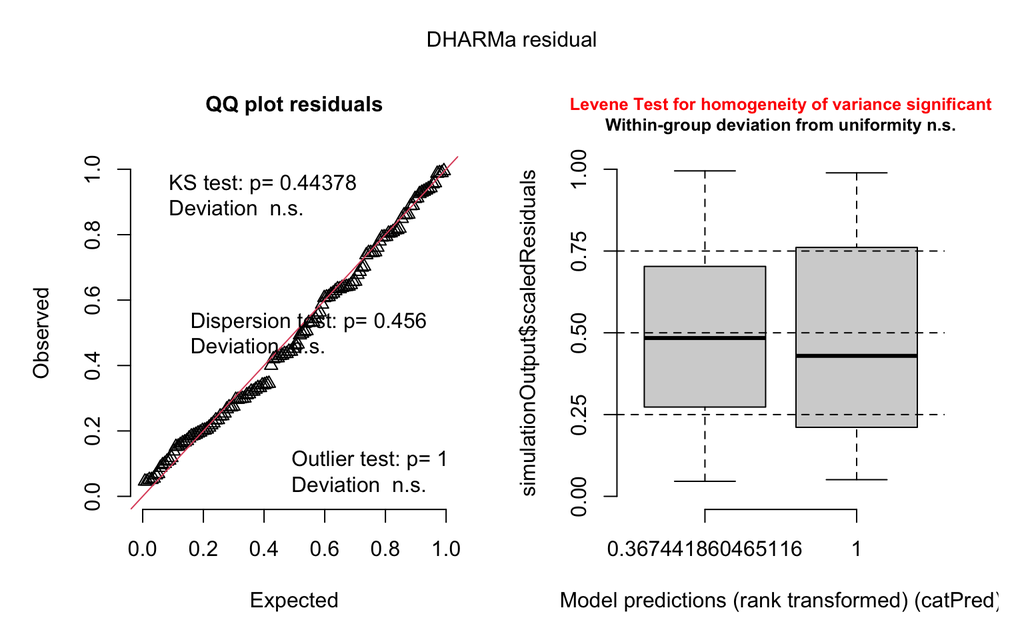

```r
sim_ldh_control_rnai <- DHARMa::simulateResiduals(
    ldh_control_rnai_model,
    n = 1000,
    seed = DHARMA_SEED
)
sim_ldh_complex_i_rescue <- DHARMa::simulateResiduals(
    ldh_complex_i_rescue_model,
    n = 1000,
    seed = DHARMA_SEED
)

plot(sim_ldh_control_rnai)
```

**Run DHARMa diagnostics**

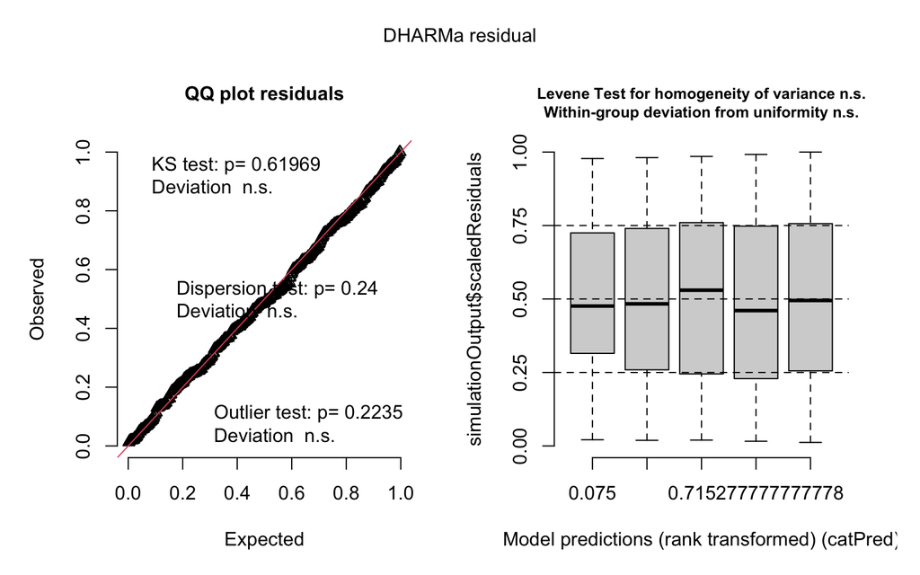

```r
plot(sim_ldh_complex_i_rescue)
```

**Run DHARMa diagnostics**

```r
invisible(capture.output(
    ldh_dharma_tests <- list(
        control_rnai_uniformity =
            DHARMa::testUniformity(sim_ldh_control_rnai, plot = FALSE),
        control_rnai_dispersion =
            DHARMa::testDispersion(sim_ldh_control_rnai, plot = FALSE),
        control_rnai_outliers =
            DHARMa::testOutliers(sim_ldh_control_rnai, plot = FALSE),
        complex_i_rescue_uniformity =
            DHARMa::testUniformity(sim_ldh_complex_i_rescue, plot = FALSE),
        complex_i_rescue_dispersion =
            DHARMa::testDispersion(sim_ldh_complex_i_rescue, plot = FALSE),
        complex_i_rescue_outliers =
            DHARMa::testOutliers(sim_ldh_complex_i_rescue, plot = FALSE)
    )
))

ldh_dharma_tests %>%
    purrr::map_dfr(
        \(t) tibble(statistic = t$statistic, p.value = t$p.value),
        .id = "test"
    ) %>%
    mutate(across(where(is.numeric), \(x) signif(x, 3)), sig = sig_stars(p.value)) %>%
    minimal_tbl()
```

| test | statistic | p.value | sig |
| --- | --- | --- | --- |
| control_rnai_uniformity | 0.0741 | 0.444 | ns |
| control_rnai_dispersion | 1.0900 | 0.456 | ns |
| control_rnai_outliers | 0.0000 | 1.000 | ns |
| complex_i_rescue_uniformity | 0.0358 | 0.620 | ns |
| complex_i_rescue_dispersion | 1.0800 | 0.240 | ns |
| complex_i_rescue_outliers | 2.0000 | 0.223 | ns |

### Global F-test

Type III ANOVA F-tests are shown separately for the left- and right-panel models.

**Type III ANOVA**

```r
ldh_anova_ctrl <- anova(ldh_control_rnai_model,    type = "III", ddf = "Satterthwaite") %>% as.data.frame()
ldh_anova_ci   <- anova(ldh_complex_i_rescue_model, type = "III", ddf = "Satterthwaite") %>% as.data.frame()

bind_rows(
    ldh_anova_ctrl %>% tibble::rownames_to_column("term") %>% mutate(model = "control_rnai"),
    ldh_anova_ci   %>% tibble::rownames_to_column("term") %>% mutate(model = "complex_i_rescue")
) %>%
    rename(df_num = NumDF, df_den = DenDF, F = `F value`, p.value = `Pr(>F)`) %>%
    select(model, term, everything()) %>%
    mutate(across(where(is.numeric), \(x) signif(x, 3)), sig = sig_stars(p.value)) %>%
    sig_tbl()
```

| model | term | Sum Sq | Mean Sq | df_num | df_den | F | p.value | sig |
| --- | --- | --- | --- | --- | --- | --- | --- | --- |
| control_rnai | condition | 2.3 | 2.3 | 1 | 24.0 | 0.621 | 0.438 | ns |
| complex_i_rescue | condition | 201.0 | 50.2 | 4 | 45.9 | 22.500 | 0.000 | *** |

The left-panel model (Control RNAi background) showed no significant condition effect ($F(1, 24) = 0.621$, $p = 0.44$). The right-panel model (CI rescue conditions) was highly significant ($F(4, 45.9) = 22.5$, $p = 2.4 \times 10^{-10}$).

### Ldh knockdown effect, Complex I aggravation, and rescue efficacy

All estimates are in EdU percentage points.

**Estimated marginal means for the control-RNAi and CI-rescue panels**

```r
ldh_control_rnai_em <- emmeans::emmeans(
    ldh_control_rnai_model,
    specs = ~ condition
)
ldh_complex_i_rescue_em <- emmeans::emmeans(
    ldh_complex_i_rescue_model,
    specs = ~ condition
)

summary(ldh_control_rnai_em)
summary(ldh_complex_i_rescue_em)
```

#### 1. Ldh knockdown alone (left panel)

`mCherry x Ldh` vs `mCherry x Luciferase`. Single comparison, no correction.

**Ldh KD vs. wild-type, left panel**

```r
ldh_alone_summary <- emmeans::contrast(
    ldh_control_rnai_em,
    method = list("mCherry x Ldh - mCherry x Luciferase" = c(-1, 1)),
    adjust = "none"
) %>%
    summary(infer = c(TRUE, TRUE)) %>%
    as_tibble()

ldh_alone_summary %>%
    mutate(across(where(is.numeric), \(x) signif(x, 3)), sig = sig_stars(p.value)) %>%
    sig_tbl()
```

| contrast | estimate | SE | df | lower.CL | upper.CL | t.ratio | p.value | sig |
| --- | --- | --- | --- | --- | --- | --- | --- | --- |
| mCherry x Ldh - mCherry x Luciferase | 0.453 | 0.576 | 25 | -0.734 | 1.64 | 0.786 | 0.439 | ns |

Ldh knockdown alone did not significantly alter NSC proliferation relative to wild-type (0.453 pp, $t(25) = 0.786$, $p = 0.44$).

#### 2. Ldh KD worsens ND42 phenotype (right panel)

`ND42 x Ldh` vs `ND42 x Luciferase`. Single comparison, no correction.

**Ldh KD + CI vs. CI alone, right panel**

```r
ldh_worsens_summary <- emmeans::contrast(
    ldh_complex_i_rescue_em,
    method = list("ND42 x Ldh - ND42 x Luciferase" = c(-1, 1, 0, 0, 0)),
    adjust = "none"
) %>%
    summary(infer = c(TRUE, TRUE)) %>%
    as_tibble()

ldh_worsens_summary %>%
    mutate(across(where(is.numeric), \(x) signif(x, 3)), sig = sig_stars(p.value)) %>%
    sig_tbl()
```

| contrast | estimate | SE | df | lower.CL | upper.CL | t.ratio | p.value | sig |
| --- | --- | --- | --- | --- | --- | --- | --- | --- |
| ND42 x Ldh - ND42 x Luciferase | -2.14 | 0.313 | 54 | -2.77 | -1.51 | -6.84 | 0 | *** |

Combined Ldh knockdown with CI dysfunction significantly reduced NSC proliferation relative to CI dysfunction alone (-2.14 pp, $t(54) = -6.84$, $p = 7.5 \times 10^{-9}$).

#### 3. Rescue vs disease baseline

Each rescue construct vs `ND42 x Ldh` (multivariate-$t$ adjusted across 3 comparisons).

**Rescue vs ND42 x Ldh (multivariate-$t$ adjusted)**

```r
ldh_em_vs_baseline <- ldh_complex_i_rescue_em[
    match(c(LDH_CI, ldh_rescues), ldh_complex_i_rescue_em@grid$condition)
]

ldh_rescue_vs_baseline_summary <- summary(
    emmeans::contrast(ldh_em_vs_baseline, method = "trt.vs.ctrl", ref = 1, adjust = "mvt"),
    infer = c(TRUE, TRUE)
)
```

| contrast | estimate | SE | df | lower.CL | upper.CL | t.ratio | p.value | sig |
| --- | --- | --- | --- | --- | --- | --- | --- | --- |
| ND42 x LdhA;Ldh | 1.880 | 0.468 | 66.4 | 0.746 | 3.02 | 4.02 | 0.000464 | *** |
| ND42 x LdhB;Ldh | -0.697 | 0.403 | 69.2 | -1.670 | 0.28 | -1.73 | 0.225000 | ns |
| ND42 x LbNox;Ldh | 1.770 | 0.390 | 40.5 | 0.809 | 2.73 | 4.54 | 0.000163 | *** |

ND42 x LdhA;Ldh and ND42 x LbNox;Ldh significantly increased proliferation relative to the `ND42 x Ldh` baseline; ND42 x LdhB;Ldh did not.

#### 4. Rescue to control level

Each rescue construct vs `ND42 x Luciferase` (multivariate-$t$ adjusted across 3 comparisons). A non-significant result indicates the condition is not detectably different from the ND42-only control, i.e. proliferation is restored.

**Rescue vs ND42 x Luciferase (multivariate-$t$ adjusted)**

```r
ldh_em_vs_control <- ldh_complex_i_rescue_em[
    match(c(LUC_CI, ldh_rescues), ldh_complex_i_rescue_em@grid$condition)
]

ldh_rescue_vs_control_summary <- summary(
    emmeans::contrast(ldh_em_vs_control, method = "trt.vs.ctrl", ref = 1, adjust = "mvt"),
    infer = c(TRUE, TRUE)
)
```

| contrast | estimate | SE | df | lower.CL | upper.CL | t.ratio | p.value | sig |
| --- | --- | --- | --- | --- | --- | --- | --- | --- |
| ND42 x LdhA;Ldh | -0.257 | 0.448 | 60.5 | -1.35 | 0.837 | -0.574 | 0.912 | ns |
| ND42 x LdhB;Ldh | -2.840 | 0.390 | 55.6 | -3.79 | -1.880 | -7.270 | 0.000 | *** |
| ND42 x LbNox;Ldh | -0.367 | 0.346 | 40.3 | -1.22 | 0.490 | -1.060 | 0.630 | ns |

## Fig S1I-J: NSC proliferation rate

NSC proliferation rate (EdU-positive progeny per clone) is compared across Control, Complex I, and Complex V RNAi, one clone per row. Two mosaic systems affect different fractions of NSCs and are analysed as separate models:

- **Most NSCs affected:** `worniu-GAL4, Tub-FRT-Stop-FRT-GFP`
- **Few NSCs affected:** `Actin-FRT-Stop-FRT-GAL4, UAS-mCD8-GFP`

Brains are the biological replicate and enter each panel’s model as a random intercept:

`EdU ~ rnai + (1 | brain_uid)`

Complex I and Complex V RNAi are each compared to the panel-matched Control RNAi, with a multivariate-$t$ adjustment across the two comparisons within a panel.

**Load Fig S1I-J proliferation-rate data and tabulate clones and brains per group**

```r
s1e_df <- read_stat("fig_s01i_j_edu.csv") %>%
    filter(!is.na(value)) %>%
    transmute(
        EdU   = value,
        panel = factor(
            if_else(panel_side == "left", "Most NSCs affected", "Few NSCs affected"),
            levels = c("Most NSCs affected", "Few NSCs affected")
        ),
        rnai      = factor(rnai, levels = c("Control", "Complex I", "Complex V")),
        brain_uid = factor(replicate_id)
    )

s1e_df %>%
    group_by(panel, rnai) %>%
    summarise(
        n_clones = n(),
        n_brains = n_distinct(brain_uid),
        .groups = "drop"
    ) %>%
    minimal_tbl()
```

| panel | rnai | n_clones | n_brains |
| --- | --- | --- | --- |
| Most NSCs affected | Control | 29 | 5 |
| Most NSCs affected | Complex I | 29 | 5 |
| Most NSCs affected | Complex V | 19 | 4 |
| Few NSCs affected | Control | 27 | 4 |
| Few NSCs affected | Complex I | 31 | 5 |
| Few NSCs affected | Complex V | 33 | 5 |

### Diagnostics

**Fit panel-specific linear mixed-effects models**

```r
s1e_most_nscs_df <- s1e_df %>%
    filter(panel == "Most NSCs affected")

s1e_few_nscs_df <- s1e_df %>%
    filter(panel == "Few NSCs affected")

s1e_most_nscs_model <- lmerTest::lmer(
    EdU ~ rnai + (1 | brain_uid),
    data = s1e_most_nscs_df,
    REML = TRUE
)

s1e_few_nscs_model <- lmerTest::lmer(
    EdU ~ rnai + (1 | brain_uid),
    data = s1e_few_nscs_df,
    REML = TRUE
)

summary(s1e_most_nscs_model)
summary(s1e_few_nscs_model)
```

**NoteModel fit diagnostics with DHARMa**

Scaled residuals from 1,000 simulations are tested for uniform distribution (Kolmogorov–Smirnov), dispersion, and an excess of outliers; all three should be non-significant for a well-fitting model.

**Run DHARMa diagnostics**

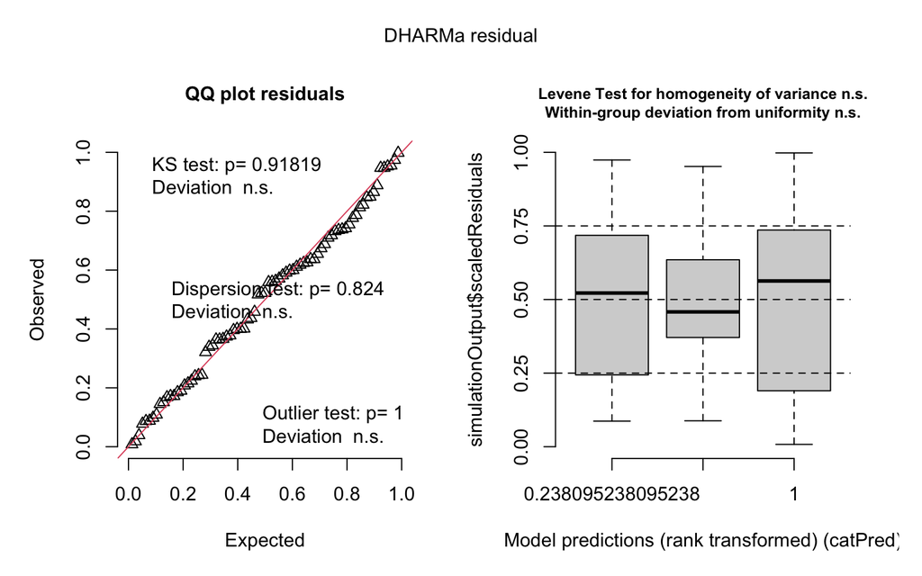

```r
sim_s1e_most_nscs <- DHARMa::simulateResiduals(
    s1e_most_nscs_model,
    n = 1000,
    seed = DHARMA_SEED
)
sim_s1e_few_nscs <- DHARMa::simulateResiduals(
    s1e_few_nscs_model,
    n = 1000,
    seed = DHARMA_SEED
)

plot(sim_s1e_most_nscs)
```

**Run DHARMa diagnostics**

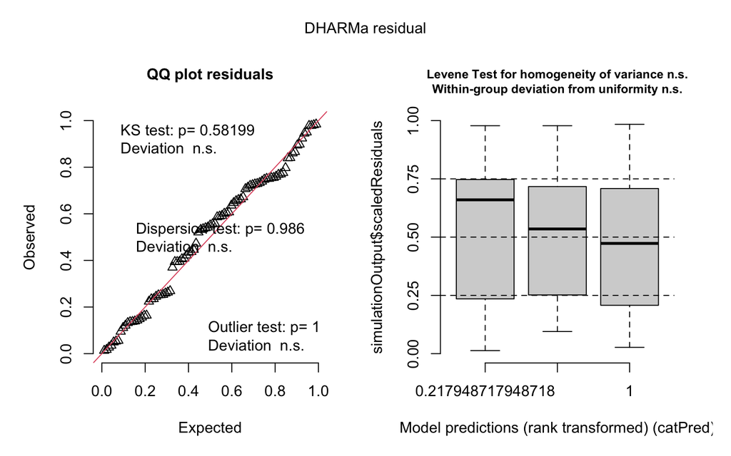

```r
plot(sim_s1e_few_nscs)
```

**Run DHARMa diagnostics**

```r
invisible(capture.output(
    s1e_dharma_tests <- list(
        most_nscs_uniformity =
            DHARMa::testUniformity(sim_s1e_most_nscs, plot = FALSE),
        most_nscs_dispersion =
            DHARMa::testDispersion(sim_s1e_most_nscs, plot = FALSE),
        most_nscs_outliers =
            DHARMa::testOutliers(sim_s1e_most_nscs, plot = FALSE),
        few_nscs_uniformity =
            DHARMa::testUniformity(sim_s1e_few_nscs, plot = FALSE),
        few_nscs_dispersion =
            DHARMa::testDispersion(sim_s1e_few_nscs, plot = FALSE),
        few_nscs_outliers =
            DHARMa::testOutliers(sim_s1e_few_nscs, plot = FALSE)
    )
))

s1e_dharma_tests %>%
    purrr::map_dfr(
        \(t) tibble(statistic = t$statistic, p.value = t$p.value),
        .id = "test"
    ) %>%
    mutate(across(where(is.numeric), \(x) signif(x, 3)), sig = sig_stars(p.value)) %>%
    minimal_tbl()
```

| test | statistic | p.value | sig |
| --- | --- | --- | --- |
| most_nscs_uniformity | 0.0632 | 0.918 | ns |
| most_nscs_dispersion | 1.0300 | 0.824 | ns |
| most_nscs_outliers | 0.0000 | 1.000 | ns |
| few_nscs_uniformity | 0.0815 | 0.582 | ns |
| few_nscs_dispersion | 0.9970 | 0.986 | ns |
| few_nscs_outliers | 0.0000 | 1.000 | ns |

### Global F-test

Type III ANOVA F-tests are shown separately for the two panel-specific models.

**Type III ANOVA**

```r
s1e_anova_most <- anova(s1e_most_nscs_model, type = "III", ddf = "Satterthwaite") %>% as.data.frame()
s1e_anova_few  <- anova(s1e_few_nscs_model,  type = "III", ddf = "Satterthwaite") %>% as.data.frame()

bind_rows(
    s1e_anova_most %>% tibble::rownames_to_column("term") %>% mutate(panel = "Most NSCs affected"),
    s1e_anova_few  %>% tibble::rownames_to_column("term") %>% mutate(panel = "Few NSCs affected")
) %>%
    rename(df_num = NumDF, df_den = DenDF, F = `F value`, p.value = `Pr(>F)`) %>%
    select(panel, term, everything()) %>%
    mutate(across(where(is.numeric), \(x) signif(x, 3)), sig = sig_stars(p.value)) %>%
    sig_tbl()
```

| panel | term | Sum Sq | Mean Sq | df_num | df_den | F | p.value | sig |
| --- | --- | --- | --- | --- | --- | --- | --- | --- |
| Most NSCs affected | rnai | 379.0 | 190.00 | 2 | 11.5 | 49.30 | 2.3e-06 | *** |
| Few NSCs affected | rnai | 11.6 | 5.78 | 2 | 11.0 | 1.23 | 3.3e-01 | ns |

The `rnai` main effect was highly significant in the Most NSCs panel ($F(2, 11.5) = 49.3$, $p = 2.3 \times 10^{-6}$) but not in the Few NSCs panel ($F(2, 11) = 1.23$, $p = 0.33$).

### Complex I and Complex V RNAi vs. Control RNAi, per panel (multivariate-$t$ adjusted)

Estimates are in EdU percentage points. Each RNAi condition is compared to the panel-matched Control RNAi group.

**Complex I and Complex V vs. Control contrasts, per panel (multivariate-$t$ adjusted)**

```r
s1e_most_nscs_em <- emmeans::emmeans(s1e_most_nscs_model, specs = ~ rnai)
s1e_few_nscs_em <- emmeans::emmeans(s1e_few_nscs_model, specs = ~ rnai)

s1e_most_nscs_contrasts <- summary(
    emmeans::contrast(
        s1e_most_nscs_em,
        method = "trt.vs.ctrl",
        ref = "Control",
        adjust = "mvt"
    ),
    infer = c(TRUE, TRUE)
) %>%
    as_tibble() %>%
    mutate(panel = "Most NSCs affected")

s1e_few_nscs_contrasts <- summary(
    emmeans::contrast(
        s1e_few_nscs_em,
        method = "trt.vs.ctrl",
        ref = "Control",
        adjust = "mvt"
    ),
    infer = c(TRUE, TRUE)
) %>%
    as_tibble() %>%
    mutate(panel = "Few NSCs affected")

s1e_contrast_results <- bind_rows(
    s1e_most_nscs_contrasts,
    s1e_few_nscs_contrasts
) %>%
    select(panel, everything()) %>%
    mutate(sig = sig_stars(p.value))
```

| panel | contrast | estimate | SE | df | lower.CL | upper.CL | t.ratio | p.value | sig |
| --- | --- | --- | --- | --- | --- | --- | --- | --- | --- |
| Most NSCs affected | Complex I - Control | -6.600 | 0.702 | 10.10 | -8.41 | -4.790 | -9.41 | 5.30e-06 | *** |
| Most NSCs affected | Complex V - Control | -5.450 | 0.778 | 11.30 | -7.42 | -3.470 | -7.00 | 4.35e-05 | *** |
| Few NSCs affected | Complex I - Control | -0.796 | 0.648 | 10.50 | -2.45 | 0.862 | -1.23 | 3.90e-01 | ns |
| Few NSCs affected | Complex V - Control | -0.947 | 0.642 | 9.97 | -2.59 | 0.696 | -1.47 | 2.79e-01 | ns |

In the Most NSCs panel, both knockdowns significantly reduced EdU relative to Control: Complex I (-6.6 pp, $p = 5.3 \times 10^{-6}$) and Complex V (-5.45 pp, $p = 4.4 \times 10^{-5}$). Neither contrast was significant in the Few NSCs panel (Complex I $p = 0.39$; Complex V $p = 0.28$), consistent with the non-significant ANOVA for that panel.

## Fig S7C: pAMPK levels and ATP depletion

Normalised pAMPK intensity is compared across Control, Complex I, and Complex V RNAi, one NSC per row, with brain as a random intercept. The response is log-transformed:

`log(normalized_intensity) ~ condition + (1 | brain_uid)`

Complex I and Complex V RNAi are each compared to Control RNAi, together with a direct Complex I vs. Complex V comparison, jointly multivariate-$t$ adjusted. Contrasts are back-transformed and reported as fold-changes relative to Control RNAi.

**Load Fig S7C pAMPK data and tabulate NSCs and brains per condition**

```r
pampk_df <- read_stat("fig_s07c_pampk.csv") %>%
    filter(!is.na(value)) %>%
    transmute(
        normalized_intensity = value,
        condition = factor(genotype,
                           levels = c("Control RNAi", "Complex I RNAi", "Complex V RNAi")),
        brain_uid = factor(replicate_id)
    )

pampk_df %>%
    group_by(condition) %>%
    summarise(
        n_measurements = n(),
        n_brains       = n_distinct(brain_uid),
        .groups        = "drop"
    ) %>%
    minimal_tbl()
```

| condition | n_measurements | n_brains |
| --- | --- | --- |
| Control RNAi | 49 | 12 |
| Complex I RNAi | 51 | 14 |
| Complex V RNAi | 50 | 13 |

### Diagnostics

**Fit brain-level linear mixed-effects model**

```r
pampk_model <- lmerTest::lmer(
    log(normalized_intensity) ~ condition + (1 | brain_uid),
    data = pampk_df,
    REML = TRUE
)
summary(pampk_model)
```

**NoteModel fit diagnostics with DHARMa**

Scaled residuals from 1,000 simulations are tested for uniform distribution (Kolmogorov–Smirnov), dispersion, and an excess of outliers; all three should be non-significant for a well-fitting model.

**Run DHARMa diagnostics**

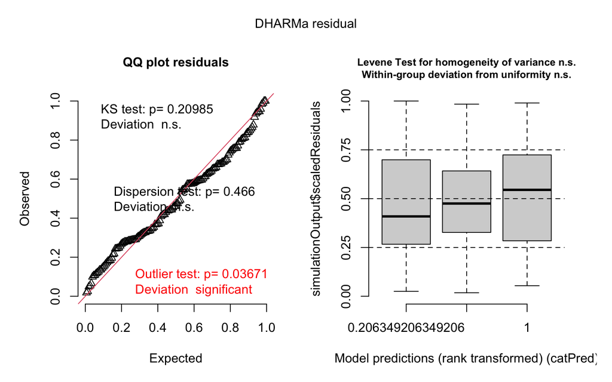

```r
sim_pampk <- DHARMa::simulateResiduals(pampk_model, n = 1000, seed = DHARMA_SEED)
plot(sim_pampk)
```

**Run DHARMa diagnostics**

```r
invisible(capture.output(
    pampk_dharma_tests <- list(
        uniformity     = DHARMa::testUniformity(sim_pampk, plot = FALSE),
        dispersion     = DHARMa::testDispersion(sim_pampk, plot = FALSE),
        outliers = DHARMa::testOutliers(sim_pampk, plot = FALSE)
    )
))

pampk_dharma_tests %>%
    purrr::map_dfr(
        \(t) tibble(statistic = t$statistic, p.value = t$p.value),
        .id = "test"
    ) %>%
    mutate(across(where(is.numeric), \(x) signif(x, 3)), sig = sig_stars(p.value)) %>%
    minimal_tbl()
```

| test | statistic | p.value | sig |
| --- | --- | --- | --- |
| uniformity | 0.0867 | 0.2100 | ns |
| dispersion | 1.0500 | 0.4660 | ns |
| outliers | 2.0000 | 0.0367 | * |

### Global F-test

Type III ANOVA (Satterthwaite degrees of freedom) on the `condition` term.

**Type III ANOVA**

```r
pampk_anova <- anova(pampk_model, type = "III", ddf = "Satterthwaite") %>%
    as.data.frame()

pampk_anova %>%
    tibble::rownames_to_column("term") %>%
    rename(df_num = NumDF, df_den = DenDF, F = `F value`, p.value = `Pr(>F)`) %>%
    mutate(across(where(is.numeric), \(x) signif(x, 3)), sig = sig_stars(p.value)) %>%
    sig_tbl()
```

| term | Sum Sq | Mean Sq | df_num | df_den | F | p.value | sig |
| --- | --- | --- | --- | --- | --- | --- | --- |
| condition | 0.109 | 0.0543 | 2 | 36.1 | 4.64 | 0.0161 | * |

### All pairwise comparisons (multivariate-$t$ adjusted)

Contrasts are computed on the log scale and back-transformed, so `ratio` is the multiplicative change in pAMPK intensity between conditions.

**Pairwise RNAi contrasts, back-transformed to fold-changes (multivariate-$t$ adjusted)**

```r
pampk_em <- emmeans::emmeans(pampk_model, specs = ~ condition)

pampk_contrast_list <- list(
    "Complex I RNAi - Control RNAi"   = c(-1,  1,  0),
    "Complex V RNAi - Control RNAi"   = c(-1,  0,  1),
    "Complex I RNAi - Complex V RNAi" = c( 0,  1, -1)
)

pampk_contrast_results <- emmeans::contrast(
    pampk_em,
    method = pampk_contrast_list,
    adjust = "mvt",
    type   = "response"
) %>%
    summary(infer = c(TRUE, TRUE)) %>%
    as_tibble() %>%
    mutate(across(where(is.numeric), \(x) signif(x, 3)), sig = sig_stars(p.value))

pampk_contrast_results %>%
    sig_tbl()
```

| contrast | ratio | SE | df | lower.CL | upper.CL | null | t.ratio | p.value | sig |
| --- | --- | --- | --- | --- | --- | --- | --- | --- | --- |
| Complex I RNAi / Control RNAi | 0.788 | 0.0649 | 35.8 | 0.644 | 0.964 | 1 | -2.890 | 0.0175 | * |
| Complex V RNAi / Control RNAi | 0.943 | 0.0790 | 35.9 | 0.768 | 1.160 | 1 | -0.705 | 0.7620 | ns |
| Complex I RNAi / Complex V RNAi | 0.836 | 0.0676 | 36.2 | 0.686 | 1.020 | 1 | -2.210 | 0.0827 | ns |

Complex I RNAi reduces pAMPK relative to Control RNAi (ratio = 0.788, $p = 0.018$); Complex V RNAi does not differ significantly from Control RNAi (ratio = 0.943, $p = 0.76$). Once brain clustering is accounted for, Complex I RNAi and Complex V RNAi are no longer significantly distinguishable from each other (ratio = 0.836, $p = 0.083$).

## Fig S7F: SOD2 rescue experiment

NSC mitotic index (% pH3⁺ among Dpn⁺) is compared in a 3 × 2 factorial of RNAi condition (`Control`, `Complex I`, `Complex V`) × SOD2 expression (`None`, `SOD2`), one brain per row (5–7 per cell). An interaction linear model is fit to the per-brain values:

`Mitotic_index ~ rnai * sod2`

**Load Fig S7F SOD2-rescue data and tabulate brains per cell**

```r
sod2_df <- read_stat("fig_s07f_sod2_rescue.csv") %>%
    filter(!is.na(value)) %>%
    transmute(
        Mitotic_index = value,
        sod2 = factor(rescue_transgene, levels = c("None", "SOD2")),
        rnai = factor(rnai,             levels = c("Control", "Complex I", "Complex V"))
    )

contrasts(sod2_df$sod2) <- contr.sum(nlevels(sod2_df$sod2))
contrasts(sod2_df$rnai) <- contr.sum(nlevels(sod2_df$rnai))

sod2_df %>%
    count(rnai, sod2, name = "n_brains") %>%
    minimal_tbl()
```

| rnai | sod2 | n_brains |
| --- | --- | --- |
| Control | None | 7 |
| Control | SOD2 | 5 |
| Complex I | None | 5 |
| Complex I | SOD2 | 5 |
| Complex V | None | 5 |
| Complex V | SOD2 | 5 |

### Diagnostics

**Fit interaction linear model (RNAi × SOD2) on per-brain mitotic index**

```r
sod2_lm_raw <- lm(Mitotic_index ~ rnai * sod2, data = sod2_df)
summary(sod2_lm_raw)
```

**NoteModel fit diagnostics with DHARMa**

Scaled residuals from 1,000 simulations are tested for uniform distribution (Kolmogorov–Smirnov), dispersion, and an excess of outliers; all three should be non-significant for a well-fitting model.

**Run DHARMa diagnostics**

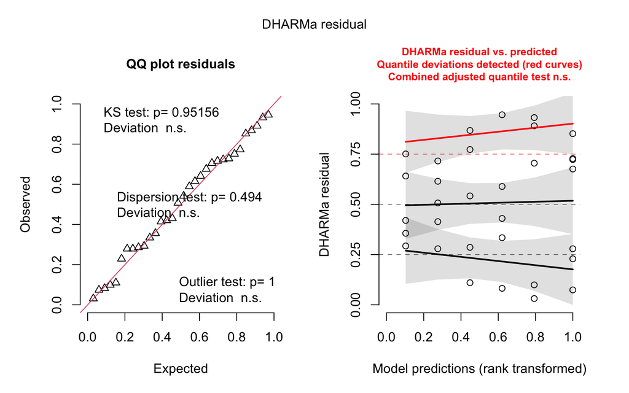

```r
sim_sod2_raw <- DHARMa::simulateResiduals(sod2_lm_raw, n = 1000, seed = DHARMA_SEED)
plot(sim_sod2_raw)
```

**Run DHARMa diagnostics**

```r
invisible(capture.output(
    sod2_dharma_tests <- list(
        uniformity     = DHARMa::testUniformity(sim_sod2_raw, plot = FALSE),
        dispersion     = DHARMa::testDispersion(sim_sod2_raw, plot = FALSE),
        outliers = DHARMa::testOutliers(sim_sod2_raw, plot = FALSE)
    )
))

sod2_dharma_tests %>%
    purrr::map_dfr(
        \(t) tibble(statistic = t$statistic, p.value = t$p.value),
        .id = "test"
    ) %>%
    mutate(across(where(is.numeric), \(x) signif(x, 3)), sig = sig_stars(p.value)) %>%
    minimal_tbl()
```

| test | statistic | p.value | sig |
| --- | --- | --- | --- |
| uniformity | 0.0915 | 0.952 | ns |
| dispersion | 0.8230 | 0.494 | ns |
| outliers | 0.0000 | 1.000 | ns |

### Global F-test

Type III ANOVA on `rnai * sod2`: the two main effects and their interaction.

**Type III ANOVA (main effects and interaction)**

```r
car::Anova(sod2_lm_raw, type = "III") %>%
    as.data.frame() %>%
    tibble::rownames_to_column("term") %>%
    rename(df = Df, F = `F value`, p.value = `Pr(>F)`) %>%
    mutate(across(where(is.numeric), \(x) signif(x, 3)), sig = sig_stars(p.value)) %>%
    sig_tbl()
```

| term | Sum Sq | df | F | p.value | sig |
| --- | --- | --- | --- | --- | --- |
| (Intercept) | 13400.0 | 1 | 481.000 | 0.0000 | *** |
| rnai | 226.0 | 2 | 4.060 | 0.0293 | * |
| sod2 | 17.1 | 1 | 0.612 | 0.4410 | ns |
| rnai:sod2 | 87.7 | 2 | 1.570 | 0.2270 | ns |
| Residuals | 725.0 | 26 | NA | NA |  |

### SOD2 vs. no SOD2, within each RNAi background (multivariate-$t$ adjusted)

The three within-background comparisons are taken from the full `rnai * sod2` estimated-marginal-means grid, with a multivariate-$t$ adjustment applied jointly across all three.

**SOD2 vs. no SOD2 within each RNAi background (multivariate-$t$ adjusted)**

```r
sod2_em <- emmeans::emmeans(sod2_lm_raw, ~ rnai * sod2)

sod2_contrast_list <- list(
    "SOD2 - None | Control"   = c(-1,  0,  0,  1,  0,  0),
    "SOD2 - None | Complex I" = c( 0, -1,  0,  0,  1,  0),
    "SOD2 - None | Complex V" = c( 0,  0, -1,  0,  0,  1)
)

sod2_contrast_results <- emmeans::contrast(
    sod2_em,
    method = sod2_contrast_list,
    adjust = "mvt"
) %>%
    summary(infer = c(TRUE, TRUE)) %>%
    as_tibble() %>%
    mutate(across(where(is.numeric), \(x) signif(x, 3)), sig = sig_stars(p.value))

sod2_contrast_results %>%
    sig_tbl()
```

| contrast | estimate | SE | df | lower.CL | upper.CL | t.ratio | p.value | sig |
| --- | --- | --- | --- | --- | --- | --- | --- | --- |
| SOD2 - None \| Control | -5.820 | 3.09 | 26 | -13.70 | 2.05 | -1.880 | 0.194 | ns |
| SOD2 - None \| Complex I | 2.070 | 3.34 | 26 | -6.44 | 10.60 | 0.618 | 0.899 | ns |
| SOD2 - None \| Complex V | -0.662 | 3.34 | 26 | -9.16 | 7.84 | -0.198 | 0.996 | ns |

## Fig S9A: Glial OxPhos knockdown and NSC background

EdU-positive progeny per NSC clone is compared across six genotypes: the two reference controls (`mCherry x Luciferase`, wild type; `ND42 x Luciferase`, CI-dysfunction baseline) and the four combinations of NSC background (`mCherry` = wild type, `ND42` = CI-dysfunction) × glial knockdown (`ND42` or `ATPsynO`), one clone per row, with brain as the biological replicate.

The data are fit with a factorial linear mixed-effects model:

`EdU ~ nsc_background * glial_gene + (1 | brain_uid)`

The `nsc_background × glial_gene` interaction tests whether the glial-knockdown effect depends on NSC background. Two simple-effect comparisons: `ND42 x ND42` vs. `mCherry x ND42` and `ND42 x ATPsynO` vs. `mCherry x ATPsynO` test whether NSC background changes the effect of each glial knockdown, jointly multivariate-$t$ adjusted.

**Load Fig S9A glial-OxPhos data and tabulate clones and brains per genotype**

```r
s8e_ox_target <- c(
    "mCherry x Luciferase", "ND42 x Luciferase",
    "mCherry x ND42", "ND42 x ND42",
    "mCherry x ATPsynO", "ND42 x ATPsynO"
)

s8e_ox_df <- read_stat("edu_glial_screen.csv") %>%
    filter(genotype %in% s8e_ox_target, !is.na(value)) %>%
    transmute(
        EdU      = value,
        Genotype = genotype,
        nsc_background = case_when(
            genotype %in% c("mCherry x Luciferase", "mCherry x ND42", "mCherry x ATPsynO") ~ "WT",
            genotype %in% c("ND42 x Luciferase", "ND42 x ND42", "ND42 x ATPsynO") ~ "CI-dysfunction"
        ),
        glial_gene = case_when(
            genotype %in% c("mCherry x Luciferase", "ND42 x Luciferase") ~ "control",
            genotype %in% c("mCherry x ND42", "ND42 x ND42") ~ "ND42",
            genotype %in% c("mCherry x ATPsynO", "ND42 x ATPsynO") ~ "ATPsynO"
        ),
        nsc_background = factor(nsc_background, levels = c("WT", "CI-dysfunction")),
        glial_gene     = factor(glial_gene, levels = c("control", "ND42", "ATPsynO")),
        brain_uid      = factor(replicate_id)
    )

stopifnot(!anyNA(s8e_ox_df$nsc_background), !anyNA(s8e_ox_df$glial_gene))

s8e_ox_df %>%
    group_by(nsc_background, glial_gene) %>%
    summarise(
        n_clones = n(),
        n_brains = n_distinct(brain_uid),
        .groups  = "drop"
    ) %>%
    minimal_tbl()
```

| nsc_background | glial_gene | n_clones | n_brains |
| --- | --- | --- | --- |
| WT | control | 78 | 16 |
| WT | ND42 | 27 | 5 |
| WT | ATPsynO | 28 | 7 |
| CI-dysfunction | control | 171 | 36 |
| CI-dysfunction | ND42 | 12 | 3 |
| CI-dysfunction | ATPsynO | 15 | 5 |

### Diagnostics

**Fit clone-level linear mixed-effects model**

```r
contrasts(s8e_ox_df$nsc_background) <- contr.sum(2)
contrasts(s8e_ox_df$glial_gene) <- contr.sum(3)

s8e_ox_lme <- lmerTest::lmer(
    EdU ~ nsc_background * glial_gene + (1 | brain_uid),
    data = s8e_ox_df,
    REML = TRUE
)
summary(s8e_ox_lme)
```

**NoteModel fit diagnostics with DHARMa**

Scaled residuals from 1,000 simulations are tested for uniform distribution (Kolmogorov–Smirnov), dispersion, and an excess of outliers; all three should be non-significant for a well-fitting model.

**Run DHARMa diagnostics**

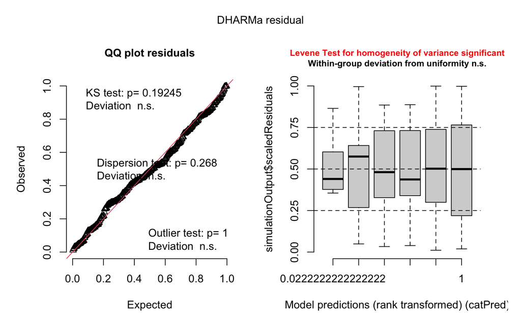

```r
sim_s8e_ox <- DHARMa::simulateResiduals(s8e_ox_lme, n = 1000, seed = DHARMA_SEED)
plot(sim_s8e_ox)
```

**Run DHARMa diagnostics**

```r
invisible(capture.output(
    s8e_ox_dharma_tests <- list(
        uniformity     = DHARMa::testUniformity(sim_s8e_ox, plot = FALSE),
        dispersion     = DHARMa::testDispersion(sim_s8e_ox, plot = FALSE),
        outliers       = DHARMa::testOutliers(sim_s8e_ox, plot = FALSE)
    )
))

s8e_ox_dharma_tests %>%
    purrr::map_dfr(
        \(t) tibble(statistic = t$statistic, p.value = t$p.value),
        .id = "test"
    ) %>%
    mutate(across(where(is.numeric), \(x) signif(x, 3)), sig = sig_stars(p.value)) %>%
    minimal_tbl()
```

| test | statistic | p.value | sig |
| --- | --- | --- | --- |
| uniformity | 0.0595 | 0.192 | ns |
| dispersion | 1.0900 | 0.268 | ns |
| outliers | 0.0000 | 1.000 | ns |

### Global F-test

Type III ANOVA (Satterthwaite degrees of freedom) on `nsc_background * glial_gene`: the two main effects and their interaction.

**Type III ANOVA (main effects and interaction)**

```r
s8e_ox_anova <- anova(s8e_ox_lme, type = "III", ddf = "Satterthwaite") %>%
    as.data.frame()

s8e_ox_anova %>%
    tibble::rownames_to_column("term") %>%
    rename(df_num = NumDF, df_den = DenDF, F = `F value`, p.value = `Pr(>F)`) %>%
    mutate(across(where(is.numeric), \(x) signif(x, 3)), sig = sig_stars(p.value)) %>%
    sig_tbl()
```

| term | Sum Sq | Mean Sq | df_num | df_den | F | p.value | sig |
| --- | --- | --- | --- | --- | --- | --- | --- |
| nsc_background | 18.4 | 18.4 | 1 | 66.2 | 7.17 | 0.009320 | ** |
| glial_gene | 60.9 | 30.5 | 2 | 66.5 | 11.90 | 0.000038 | *** |
| nsc_background:glial_gene | 6.2 | 3.1 | 2 | 66.5 | 1.21 | 0.304000 | ns |

Both main effects are significant: `nsc_background` ($F(1, 66.2) = 7.17$, $p = 0.0093$) and `glial_gene` ($F(2, 66.5) = 11.9$, $p = 3.8 \times 10^{-5}$), confirming that CI-dysfunction NSCs proliferate less overall and that glial OxPhos knockdown reduces proliferation overall. The interaction is not significant ($F(2, 66.5) = 1.21$, $p = 0.3$).

### NSC background within each glial knockdown (multivariate-$t$ adjusted)

These test whether NSC background affects proliferation within each glial-knockdown condition, taken from the full `nsc_background * glial_gene` estimated-marginal-means grid and jointly multivariate-$t$ adjusted.

**NSC-background simple effects within each glial knockdown (multivariate-$t$ adjusted)**

```r
s8e_ox_em <- emmeans::emmeans(s8e_ox_lme, ~ nsc_background * glial_gene)

s8e_ox_contrast_list <- list(
    "ND42 x ND42 - mCherry x ND42"       = c(0, 0, -1, 1, 0, 0),
    "ND42 x ATPsynO - mCherry x ATPsynO" = c(0, 0, 0, 0, -1, 1)
)

s8e_ox_contrast_results <- emmeans::contrast(
    s8e_ox_em,
    method = s8e_ox_contrast_list,
    adjust = "mvt"
) %>%
    summary(infer = c(TRUE, TRUE)) %>%
    as_tibble() %>%
    mutate(across(where(is.numeric), \(x) signif(x, 3)), sig = sig_stars(p.value))

s8e_ox_contrast_results %>%
    sig_tbl()
```

| contrast | estimate | SE | df | lower.CL | upper.CL | t.ratio | p.value | sig |
| --- | --- | --- | --- | --- | --- | --- | --- | --- |
| ND42 x ND42 - mCherry x ND42 | -1.75 | 1.020 | 65.0 | -4.09 | 0.582 | -1.72 | 0.172 | ns |
| ND42 x ATPsynO - mCherry x ATPsynO | -1.57 | 0.868 | 77.8 | -3.55 | 0.409 | -1.81 | 0.143 | ns |

Both comparisons trend in the expected direction, CI-dysfunction NSCs proliferate less than wild-type NSCs when the glia also has `ND42` (-1.75 EdU pp, $p = 0.17$) or `ATPsynO` (-1.57 EdU pp, $p = 0.14$) knocked down, but neither reaches significance.

### Glial knockdown vs. pooled controls, within each NSC background (multivariate-$t$ adjusted)

These compare each glial-knockdown genotype against the pooled `Luciferase` control *within* the matching NSC background, testing whether glial knockdown affects wild-type and CI-dysfunction NSCs differently. All four comparisons are taken from the `nsc_background * glial_gene` grid and jointly multivariate-$t$ adjusted.

**Glial knockdown vs. pooled control within each NSC background (multivariate-$t$ adjusted)**

```r
s8e_ox_vs_control_list <- list(
    "mCherry x ND42 - mCherry x Luciferase"    = c(-1,  0,  1,  0,  0,  0),
    "mCherry x ATPsynO - mCherry x Luciferase" = c(-1,  0,  0,  0,  1,  0),
    "ND42 x ND42 - ND42 x Luciferase"          = c( 0, -1,  0,  1,  0,  0),
    "ND42 x ATPsynO - ND42 x Luciferase"       = c( 0, -1,  0,  0,  0,  1)
)

s8e_ox_vs_control_results <- emmeans::contrast(
    s8e_ox_em,
    method = s8e_ox_vs_control_list,
    adjust = "mvt"
) %>%
    summary(infer = c(TRUE, TRUE)) %>%
    as_tibble() %>%
    mutate(across(where(is.numeric), \(x) signif(x, 3)), sig = sig_stars(p.value))

s8e_ox_vs_control_results %>%
    sig_tbl()
```

| contrast | estimate | SE | df | lower.CL | upper.CL | t.ratio | p.value | sig |
| --- | --- | --- | --- | --- | --- | --- | --- | --- |
| mCherry x ND42 - mCherry x Luciferase | -1.59 | 0.696 | 58.6 | -3.37 | 0.194 | -2.28 | 0.09800 | ns |
| mCherry x ATPsynO - mCherry x Luciferase | -1.03 | 0.641 | 67.3 | -2.66 | 0.612 | -1.60 | 0.37600 | ns |
| ND42 x ND42 - ND42 x Luciferase | -2.91 | 0.857 | 69.1 | -5.10 | -0.725 | -3.40 | 0.00449 | ** |
| ND42 x ATPsynO - ND42 x Luciferase | -2.16 | 0.719 | 81.3 | -3.99 | -0.333 | -3.01 | 0.01390 | * |

Within the wild-type NSC background, neither glial knockdown reaches significance relative to `Luciferase` control (`ND42`: -1.59 EdU pp, $p = 0.098$; `ATPsynO`: -1.03 EdU pp, $p = 0.38$), though the `ND42` comparison trends toward a reduction. Within the CI-dysfunction NSC background, both glial knockdowns significantly reduce proliferation relative to `Luciferase` control (`ND42`: -2.91 EdU pp, $p = 0.0045$; `ATPsynO`: -2.16 EdU percentage-points, $p = 0.014$).

## Fig S9I: Glial LbNox and CI dysfunction rescue

EdU-positive progeny per NSC clone is compared across three genotypes differing in glial LbNox expression and NSC metabolic state, one clone per row, with brain as the biological replicate. VNCs from different imaging sessions or genotypes are counted as distinct brains. The three genotypes are:

- `mCherry x Luciferase` ($n = 78$, 16 brains): shared WT control pool.
- `mCherry x LbNox` ($n = 59$, 11 brains): glial LbNox in a WT NSC background, testing whether glial LbNox alone affects proliferation.
- `ND42 x LbNox` ($n = 34$, 7 brains): glial LbNox with CI-deficient NSCs, testing whether NSC metabolic state modifies the glial LbNox effect.

All three conditions are fit in one clone-level linear mixed-effects model with brain as a random intercept, `EdU ~ condition + (1 | brain_uid)`.

Three comparisons, specified a priori from the experimental design, are tested together with a joint multivariate-$t$ adjustment:

1. `mCherry x LbNox` vs `mCherry x Luciferase`: does glial LbNox reduce WT NSC proliferation?
2. `ND42 x LbNox` vs `mCherry x LbNox`: is the LbNox effect reversed in CI-deficient NSCs?
3. `ND42 x LbNox` vs `mCherry x Luciferase`: is proliferation in CI-deficient NSCs with glial LbNox restored to the WT level?

**Load Fig S9I glial-LbNox data and tabulate clones and brains per condition**

```r
LUC_WT_S9I   <- "mCherry x Luciferase"
LBNOX_WT_S9I <- "mCherry x LbNox"
LBNOX_CI_S9I <- "ND42 x LbNox"

s8j_conditions <- c(LUC_WT_S9I, LBNOX_WT_S9I, LBNOX_CI_S9I)

s8j_df <- read_stat("edu_glial_screen.csv") %>%
    filter(!is.na(value), genotype %in% s8j_conditions) %>%
    transmute(
        EdU       = value,
        date      = collection_date,
        brain_uid = replicate_id,
        condition = factor(genotype, levels = s8j_conditions)
    )

s8j_df %>%
    group_by(condition) %>%
    summarise(
        n_clones = n(),
        n_brains = n_distinct(brain_uid),
        n_dates  = n_distinct(date),
        .groups  = "drop"
    ) %>%
    minimal_tbl()
```

| condition | n_clones | n_brains | n_dates |
| --- | --- | --- | --- |
| mCherry x Luciferase | 78 | 16 | 4 |
| mCherry x LbNox | 59 | 11 | 3 |
| ND42 x LbNox | 34 | 7 | 6 |

### Diagnostics

**Fit linear mixed-effects model**

```r
s8j_model <- lmerTest::lmer(
    EdU ~ condition + (1 | brain_uid),
    data    = s8j_df,
    REML    = TRUE,
    control = lme4::lmerControl(optimizer = "bobyqa")
)

summary(s8j_model)
```

**NoteModel fit diagnostics with DHARMa**

Scaled residuals from 1,000 simulations are tested for uniform distribution (Kolmogorov–Smirnov), dispersion, and an excess of outliers; all three should be non-significant for a well-fitting model.

**Run DHARMa diagnostics**

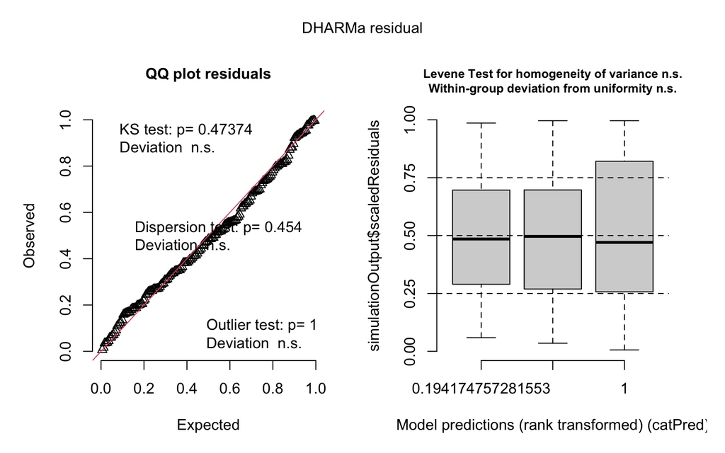

```r
sim_s8j <- DHARMa::simulateResiduals(s8j_model, n = 1000, seed = DHARMA_SEED)
plot(sim_s8j)
```

**Run DHARMa diagnostics**

```r
invisible(capture.output(
    s8j_dharma_tests <- list(
        uniformity    = DHARMa::testUniformity(sim_s8j, plot = FALSE),
        dispersion    = DHARMa::testDispersion(sim_s8j, plot = FALSE),
        outliers = DHARMa::testOutliers(sim_s8j, plot = FALSE)
    )
))

s8j_dharma_tests %>%
    purrr::map_dfr(
        \(t) tibble(statistic = t$statistic, p.value = t$p.value),
        .id = "test"
    ) %>%
    mutate(across(where(is.numeric), \(x) signif(x, 3)), sig = sig_stars(p.value)) %>%
    minimal_tbl()
```

| test | statistic | p.value | sig |
| --- | --- | --- | --- |
| uniformity | 0.0646 | 0.474 | ns |
| dispersion | 1.0800 | 0.454 | ns |
| outliers | 0.0000 | 1.000 | ns |

### Global F-test

Type III ANOVA (Satterthwaite degrees of freedom) on the `condition` term.

**Type III ANOVA**

```r
s8j_anova_res <- anova(s8j_model, type = "III", ddf = "Satterthwaite") %>%
    as.data.frame()

s8j_anova_res %>%
    tibble::rownames_to_column("term") %>%
    rename(df_num = NumDF, df_den = DenDF, F = `F value`, p.value = `Pr(>F)`) %>%
    mutate(across(where(is.numeric), \(x) signif(x, 3)), sig = sig_stars(p.value)) %>%
    sig_tbl()
```

| term | Sum Sq | Mean Sq | df_num | df_den | F | p.value | sig |
| --- | --- | --- | --- | --- | --- | --- | --- |
| condition | 17.5 | 8.74 | 2 | 26.7 | 2.27 | 0.123 | ns |

The `condition` term was not significant ($F(2, 26.7) = 2.27$, $p = 0.12$).

### Glial LbNox effect and proliferation restoration in CI-deficient NSCs

All estimates are in EdU percentage points.

**Estimated marginal means per condition**

```r
s8j_em <- emmeans::emmeans(s8j_model, specs = ~ condition)
summary(s8j_em)
```

**The three LbNox contrasts (multivariate-$t$ adjusted)**

```r
s8j_contrast_list <- list(
    "mCherry x LbNox - mCherry x Luciferase" = c(-1,  1,  0),
    "ND42 x LbNox - mCherry x LbNox"          = c( 0, -1,  1),
    "ND42 x LbNox - mCherry x Luciferase"     = c(-1,  0,  1)
)

s8j_contrasts_summary <- emmeans::contrast(s8j_em, method = s8j_contrast_list, adjust = "mvt") %>%
    summary(infer = c(TRUE, TRUE)) %>%
    as_tibble()

s8j_contrasts_summary %>%
    mutate(across(where(is.numeric), \(x) signif(x, 3)), sig = sig_stars(p.value)) %>%
    sig_tbl()
```

| contrast | estimate | SE | df | lower.CL | upper.CL | t.ratio | p.value | sig |
| --- | --- | --- | --- | --- | --- | --- | --- | --- |
| mCherry x LbNox - mCherry x Luciferase | -0.909 | 0.553 | 29.0 | -2.270 | 0.453 | -1.640 | 0.242 | ns |
| ND42 x LbNox - mCherry x LbNox | 1.350 | 0.690 | 29.1 | -0.353 | 3.050 | 1.950 | 0.141 | ns |
| ND42 x LbNox - mCherry x Luciferase | 0.440 | 0.658 | 30.0 | -1.180 | 2.060 | 0.669 | 0.782 | ns |

All three contrasts are non-significant. The key contrast (`ND42 x LbNox` − `mCherry x LbNox`, 1.35 EdU pp, $t(29.1) = 1.95$, $p = 0.14$) is in the expected direction but does not survive multivariate-$t$ correction.

## Software and Statistical Analysis

All analyses were performed in R using linear and generalized least-squares models (`stats::lm`, `nlme::gls`), linear mixed-effects models (`lme4`, `lmerTest`), estimated marginal means and multiplicity-corrected contrasts (`emmeans`), Type III ANOVA (`car`, `lmerTest`), and simulation-based residual diagnostics (`DHARMa`). Data handling used the `tidyverse`; tables and figures used `kableExtra` and `reactable`. The per-analysis data tables are in `statistical_analysis/data/`, one row per clone, brain, or cell.

Reported p-values are two-sided. Small, pre-specified contrast sets use a multivariate-$t$ adjustment; the large glial RNAi screen uses a Benjamini-Hochberg FDR correction. A fixed random seed is set for the model diagnostics and for the multivariate-$t$ computation, so all reported values are reproducible. Complete package versions are given in the Session Information below.

[session information not shown]